# Ecological Archives E095-177-metadata

*Ecological Archives* E095-177-D1

Yunjian Luo, Xiaoquan Zhang, Xiaoke Wang, Fei Lu. 2014. Biomass and its allocation of Chinese forest ecosystems. *Ecology* 95:2026. http://dx.doi.org/10.1890/13-2089.1

Introduction

Biomass and its allocation have long been considered key characteristics of forest ecosystems (Cannell 1982, Houghton et al. 2009), as these factors are important determinants of forest ecosystem structure and function. More specifically, understanding forest community dynamics, life-history evolution, and terrestrial carbon cycling and management requires quantitative assessments of forest biomass and allocation (Niklas and Enquist 2002, Houghton et al. 2009).

The International Biological Programme (IBP) from the mid-1960s to 1970s marked the onset of large-scale ecological and environmental studies in nutrient and energy flow field experiments. Subsequently, data on forest biomass and allocation patterns have been compiled in regional (e.g., northern Eurasia, Usoltsev 2001) and global (e.g., Cannell 1982, Keith et al. 2009) data sets. These data sets have been used in exploring general ecological questions, including plant allometric scaling laws (Enquist and Niklas 2002), environmental acclimation (e.g. optimal partitioning theory; McCarthy and Enquist 2007), and large-scale forest biomass patterns (Keith et al. 2009). In addition, the data have been applied to analyze biomass factors (e.g., biomass expansion factors, root-shoot ratio) in quantifying forest carbon dynamics (Teobaldelli et al. 2009). Although these data serve an important role in establishing general forest principles and patterns, the studies are primarily limited to forests of America and Europe.

One region of the world where data is clearly lacking is Eastern Asia. China, for example, has a broad climatic gradient from cold-temperate to tropical zones, and a wide variety of forest ecosystems, from tropical to boreal forests (Zhang 2007). In the late 1970s, China initiated studies to measure forest biomass and its allocation patterns (e.g., Pan et al. 1978, Zhu and Yang 1979). Subsequently, studies have examined nearly all climatic zones and forest types in China. To date, forest biomass and allocation datasets have been compiled for specific forest types (e.g., *Larix* forest, Zhou et al. 2002), forest regions (e.g., northeast China, Wang et al. 2008), and over specific time periods (e.g., from 1978 to 1996, Luo 1996, Feng et al. 1999). However, these data sets were limited in scope (e.g., surveyed one forest region, or over a short time period), and often employed different screening criteria for data inclusion.

Therefore, we developed a comprehensive forest biomass data set for China, from a wide range of survey data obtained from the literature, which was standardized, and quality-checked. The data set provides a substantial geographic extension in previously available data sets for China's forests (Luo 1996, Feng et al. 1999, Zhou et al. 2002, Wang et al. 2008), and also fills an important data gap in existing regional (e.g. Usoltsev 2001) and global data sets (e.g., Cannell 1982, Keith et al. 2009). Moreover, the dataset can be considered a transparent tool to verify the accuracy of models used to budget China's forest carbon dynamics, and also provides an opportunity to further elucidate and confirm general questions in ecology, including plant allometric scaling laws (Enquist and Niklas 2002), principles underlying plant biomass allocation (e.g., optimal partitioning theory; Poorter et al. 2012), and plant life-history evolution (McCarthy et al. 2007). In addition, the data set is freely available for non-commercial scientific uses, provided it is appropriately cited.

Metadata

Class I. Data set descriptors

**A. Data set identity**: Comprehensive forest biomass dataset of China, version 1.0

**B. Data set identification code**: CForBioData_v1.0.txt

**C. Data set description**

(1) Originators:

Xiaoke Wang, State Key Laboratory of Urban and Regional Ecology, Research Center for Eco-Environmental Sciences, Chinese Academy of Sciences, 18 Shuangqing Road, Haidian District, Beijing 100085, China;

Xiaoquan Zhang, The Nature Conservancy China Program, 9 Jianguomenwai Avenue, Chaoyang District, Beijing 100600, China;

Yunjian Luo, Key Laboratory of Urban Environment and Health, Institute of Urban Environment, Chinese Academy of Sciences, 1799 Jimei Avenue, Jimei District, Xiamen 361021, China.

**(2) Abstract:** Forest biomass and its allocation have long been considered important in forest ecosystem structure and function. However, discrete forest biomass data and its allocation to various forest components must be standardized to explore many ecological questions, e.g., plant allometric scaling laws, biomass allocation theory, and terrestrial carbon cycling. Currently, available data sets focus either on regions other than China, or studies in China are spatially and/or temporally limited, e.g., specific habitats and/or time periods. Therefore, the applicability of conclusions to world or China forests might be problematic. Consequently, in the present study, published studies (during the 1978–2008 period) on biomass and its allocations in China’s forests (excluding Hong Kong, Macao, and Taiwan) were collected, critically reviewed, and a comprehensive forest biomass data set of China was developed. The data set included the following biomass data: tree overstory components (stems, branches, leaves, and roots, among all other plant material), the understory vegetation (saplings, shrubs, herbs, and mosses), woody liana vegetation, and the necromass components of dead organic matter (litterfall, suspended branches, and dead trees). Moreover, associated information was also included, i.e., geographical location, climate, soil fertility, stand description, sampling regime (the dimension and sample size of plots), and biomass measurement methods. The data set included 1607 entries for 348 study sites, which exhibited a broad spatial distribution, and covered broad climatic gradients (-5.1–23.8°C in mean annual temperature and 223–2515 mm in mean annual precipitation). Our data set can be used to verify the accuracy of models used to budget China’s forest carbon dynamics, and also provides an opportunity to further elucidate and confirm general principles and patterns in ecology. Finally, the data set is freely available for noncommercial scientific applications.

**D. *Key words***: *allocation; biomass; China; climate; forest type; necromass; stand structure.*

Class II. Research origin descriptors

**A. Overall project description**

**(1) Identity:** Comprehensive forest biomass dataset of China, version 1.0

**(2) Originators:** X. Wang, X. Zhang, and Y. Luo

**(3) Period of Study:** From January 1978 to December 2008

**(4) Objectives:** We conducted a complete literature survey of published studies on forest biomass and its allocations across China to develop a comprehensive forest biomass dataset for China. The dataset can be used to examine regional patterns of forest biomass and its allocation, and analyze China's biomass factors (e.g. biomass expansion factors and root-shoot ratio) to quantify forest carbon dynamics.

**(5) Abstract:** Same as above.

**(6) Sources of funding:** This work was supported by the Strategic Priority Program of Chinese Academy of Sciences (XDA05060102 and XDA05050602), Fujian Provincial S&T Program (2013Y0083), and Forestry Public Welfare Program of China (201304205)

**B. Specific subproject description**

**(1) Site description:**

**(a) Site type:** Data were derived from 348 study sites, exhibiting a broad spatial distribution throughout China (Fig. 1).

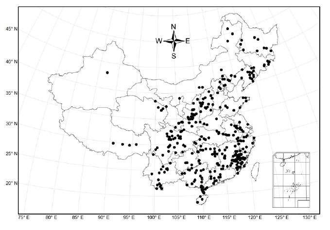

**Fig. 1.** Spatial distribution of study sites throughout China. Province boundaries are also shown.

**(b) Geography:** Various.

**(c) Habitat:** The data set represented the diversity of ecosystems and habitat types throughout China, from tropical to boreal forests.

**(d) Geology:** Various.

**(e) Watershed/hydrology:** N/A.

**(f) Site history:** Various.

**(g) Climate:** Study sites represented all climatic zones, spanning cold-temperate to tropical. The sites ranged from -5.1 to 23.8 °C in mean annual temperature (MAT), and 223 to 2515 mm in mean annual precipitation (MAP).

**(2) Design characteristics:**

Based on dominant tree species inventories and forest community type lists (Wu 1997, Zhang 2007), we attempted to compile the most complete published studies on biomass and its allocation from China's forests (excluding Hong Kong, Macao, and Taiwan). Studies published between 1978 and 2008 were retrieved from reference lists of existing forest biomass datasets (Luo 1996, Fang et al. 1999, Zhou et al. 2002, Wang et al. 2008), libraries (National Library of China, and Forestry Library of China), and online full-text databases (China Knowledge Resource Integrated Database (http://www.cnki.net/), China Science and Technology Journal Database (http://www.cqvip.com/), and Wanfang Data (http://www.wanfangdata.com/)).

**(3) Data collection:**

A critical review of the studies and measurements collected from the above sources was conducted to obtain reliable biomass data using the following criteria:

**(a) Scope:** Forest stands included in the datasets were restricted to those not recently disturbed by pruning, thinning, coppicing, fire, and insect pests, among other disturbances, and/or were not occurring in atypical sites (e.g., urban, desert, riparian, timberline, and heavily eroded). Data from the following stand types were not examined: tree crops (e.g., trees for producing edible oils, industrial raw materials, fruits, and medicinal herbs), agroforestry systems (stands interplanted with crops), and wetland forests (swamp, peatland, and intertidal forests).

**(b) Study design and sampling:** Study design and field/survey sampling descriptions should be provided in the original studies, and included the following methodology: survey period (generally during the growing season for deciduous or mixed deciduous-evergreen forests), experimental design, including sample size, establishment of sample plots (dimension), and quadrats within plots, if necessary, and biomass and necromass measurement methodology (cf. Feng et al. 1999). Sample plot dimensions varied with stand condition, forest types, and investigation objectives. Generally, the sample plot dimension was not less than 100 m² for boreal and temperate forests, 400 m² for subtropical forests, and 1000 m² for tropical forests (cf. Ni et al. 2001).

**(c) Estimates of tree biomass:** Tree-level biomass (oven-dried mass) was measured by destructive harvesting and weighing of tree components (e.g. stems, branches, leaves, and roots), and subsequently scaled up to the stand level (oven-dried mass per unit area). Specifically, stand-level tree biomass was determined using one of three following methods:

1. **Clearcutting:** All trees within a sample plot were felled, and tree components (e.g., stems, branches, leaves, and roots) were weighed. Stand-level biomass of tree components, and component sums were calculated based on the plot dimension.
2. **Average tree:** Based on statistical analyses, typically average DBH (diameter at breast height) of all trees, or average DBH within each DBH class in a sample plot, specific trees with average DBH were selected for felling and weighing of various tree components. The number of trees depended on tree species, forest type, and DBH distribution. Stand-level biomass of tree components and biomass sum was calculated based on tree numbers and sample plot dimension.
3. **Allometry:** Tree biomass measurements from all DBH classes were used to develop allometric equations integrating one or more stand measured variables (e.g., DBH, tree height, or a combination of variables) as predictors for a study site and a forest type, which were subsequently applied to estimate stand-level biomass of tree components, and the sum of these components based on tree numbers and sample plot dimensions.

We collected stand-level biomass data that estimated clearcutting or average tree methods from original studies. However, for allometric equation studies, we only collected reliable stand-level biomass data that applied unique allometric equations developed specifically for each individual study.

Furthermore, stand-level aboveground biomass data were not included where data from one or both tree components (branches and leaves) were not measured. In addition, stand-level root biomass data were not included if they did not meet the following criteria:

1. The data must represent entire root system biomass (including root crown and different diameter roots).
2. The tree-level root biomass was measured, either using the full-excavation method for the entire root system, or a hybrid method of full-excavation for the root system (excluding fine roots), and soil pit method (or soil coring method) for fine roots.
3. The excavation area was greater than or equal to the average area the trees covered, and the excavation depth reached the depth where roots were nearly absent. The roots of understory vegetation, which can be visually distinguished from the roots of trees, were removed manually.

**(d) Estimates of understory biomass:** Stand-level understory vegetation biomass data were collected if the data represented the biomass of aboveground components and/or the entire root system; and the results were estimated using reliable empirical field and analytical methods. If a certain understory type (saplings, shrubs, herbs, and mosses) did not occur in forest stands based on the stand description in the original study, its biomass was denoted as zero. A quadrat harvesting method was commonly used to determine the stand-level biomass for different understory types. Several quadrats (≥ 3) with a given area (generally ≥ 1 m²) were randomly established within a sample plot. Sample size and quadrat area varied with stand condition, understory type, and investigation objectives. The aboveground understory biomass within a quadrat was measured using destructive harvesting methods, and root biomass was measured using full-excavation methods. Tree roots were visually distinguished from the understory vegetation, and manually removed from all roots in a quadrat when measuring root biomass. Stand-level biomass of each understory type was calculated based on the quadrat area, and total understory biomass was the biomass sum of all understory types.

**(e) Woody liana biomass estimates:** Stand-level biomass data of woody lianas were compiled if the data included total biomass of above- and belowground plant components, and results were determined using reliable empirical field and analytical methods. Woody liana biomass was usually evaluated using a quadrat harvesting or allometry method.

1. **Quadrat harvesting method:** See Section (d).
2. **Allometry method:** Approaches similar to the allometry method in Section (c) were applied for woody lianas. Biomass measurements from woody lianas were obtained from all diameter classes, and allometric equations using both predictor variables (the diameter and the liana length) were developed for individual study site and forest type. The results were subsequently used to estimate stand-level biomass of woody lianas based on liana number and sample plot dimensions.

**(f) Necromass estimates:** Stand-level necromass data of dead organic matter (DOM) were collected if the data represented the necromass of different DOM types (e.g., litterfall and dead trees) and/or necromass sum, and results were estimated using reliable empirical field and analytical methods. If a certain DOM type did not occur in forest stands based on the stand description in the original study, its necromass was denoted as zero.

DOM takes various positions (e.g., standing and fallen), forms (e.g., branches, leaves, and trees), sizes (e.g., diameter and length), and decay classes in forest ecosystems. DOM attributes were always considered in our data compilation. However, few studies considered DOM sizes and decay classes, particularly sizes. Therefore, to standardize the necromass data in original studies, we did not include DOM size and decay classes, and classified DOM into the following three types based on position and form: litterfall, suspended branches, and dead trees.

1. **Litterfall:** Litterfall included all dead plant organs (e.g., branches, leaves, flowers, and seeds) in various decay classes confined to the substrate. The quadrat harvesting method was used to determine the litterfall necromass. Some quadrats (≥ 3) with a given area (generally ≥ 1 m²) were randomly established within a sample plot, and litterfall within a quadrat was collected, dried, and weighed. From oven-dried litterfall weight, stand-level necromass was calculated based on quadrat area.
2. **Suspended branches:** Suspended branches were defined as all dead branches in various decay classes that remained suspended on living trees. Necromass was determined using the average tree or allometry methods from Section (c). Suspended branch stand-level necromass was calculated based on tree numbers and sample plot dimensions.
3. **Dead trees:** Dead trees were comprised of standing and fallen trees, the latter restricted to the substrate, in various decay classes. Necromass was determined using the average tree or allometry methods from Section (c). Dead tree stand-level necromass was calculated based on dead tree numbers and sample plot dimensions. Dead root necromass was not included in the dead tree necromass data, because the dead roots were not consistently measured across studies.

**(g) Quality control:** Data were evaluated for quality to determine if they were included with our required degree of confidence. The empirical field, analytical assessments, and conclusions had to meet the following criteria: (i) data were clearly documented; (ii) experimental methodology was robust, e.g., adequate sample size, quadrat and plot numbers; iii) data were assessed for pseudoreplication; iv) appropriate statistical measures were applied. Specific types of assessment were as follows: if a measured value, (e.g., biomass or necromass) was more (or less) than twice the value in a similar growth stage and site condition it was considered suspect data. An expert rechecked all these forms of data to determine inclusion in our data set.

Consequently, 516 studies were selected from thousands, and measurements that met the above criteria were compiled to develop a comprehensive forest biomass data set representative of China. The data set includes biomass data measured in oven-dried mass per unit area (Mg ha<sup>-1</sup>) of tree components (stems, branches, leaves, roots, and other plant materials), understory vegetation (saplings, shrubs, herbs, and mosses) and woody lianas, and necromass (litterfall, suspended branches, and dead trees) data. Moreover, associated information, if available was included, i.e., geographical location (latitude (°), longitude (°), and altitude (m)), climate (mean annual temperature (MAT, °C) and mean annual precipitation (MAP, mm)), stand description (forest type, dominant tree species, stand origin, stand age (years), mean DBH (cm), mean tree height (m), stand density (trees ha<sup>-1</sup>), and growing stock volume (m3 ha<sup>-1</sup>)), sampling regime (plot dimension and number), and methods for measuring tree biomass.

**(4) Estimates and evaluation of missing data:**

Some original studies did not report growing stock volume, geographic location, and reliable climatic data (MAT and MAP). Furthermore, study site soil fertility was approximately expressed using soil fertility level. Missing variables and soil fertility levels were estimated as follows:

**(a) Growing stock volume:** Growing stock volumes were estimated for stands without actual measurements, but with the adequate available information (mean DBH, mean tree height, and stand density). Stands, which had actual growing stock volume (GSV), mean DBH, mean tree height (H) and stand density (D) measurements were used to quantify the relationship between measured GSV (GSVm) and estimated GSV (GSVe). GSVe was determined by multiplying mean stem volume, which was calculated using a conical shape model (West 2009), with stand density, i.e., GSVe=1/3·π·(DBH/2)2·H·D. A simple correction factor, *f*, was estimated as the slope of regression line through the origin (GSVm=GSVe·*f*). Significant (*P* < 0.001) regression lines with high *R*2 values were detected for forest types (groups) (Table 1). Finally, forest type-specific values of *f* were used to adjust estimated GSVs for those stands without measured GSVs, but with adequate available information.

**Table 1.** Relationships between measured (GSVm) and estimated (GSVe) growing stock volumes for forest types (groups) in China. The relationship is expressed as GSVm = GSVe·*f*, where *f* is a simple correction factor. SE is the standard error of factor *f*, *n* is the sample size, *R*2 is the coefﬁcient of determination, and SEE is standard error of the estimate.

| **Forest type (group)** | *f* **(SE)** | *n* | *R***²** | **SEE** |
| --- | --- | --- | --- | --- |
| *Abies* and *Picea* | 1.421 (0.058) | 13 | 0.830 | 35.322 |
| *Cunninghamia lanceolata* | 1.534 (0.009) | 171 | 0.987 | 20.006 |
| *Cupressus* and *Fokienia* | 1.511 (0.022) | 16 | 0.992 | 10.843 |
| *Larix* | 1.401 (0.026) | 50 | 0.931 | 22.102 |
| *Pinus koraiensis* | 1.416 (0.035) | 22 | 0.932 | 29.689 |
| *P. massoniana* | 1.425 (0.020) | 51 | 0.977 | 22.316 |
| *P. tabuliformis* | 2.018 (0.033) | 32 | 0.973 | 7.906 |
| Other pines | 1.500 (0.027) | 32 | 0.979 | 15.121 |
| Other conifers | 1.657 (0.054) | 22 | 0.940 | 38.806 |
| Deciduous broadleaved forests | 1.442 (0.056) | 29 | 0.880 | 25.485 |
| *Acacia*, *Casuarina* and *Eucalyptus* | 1.385 (0.025) | 43 | 0.974 | 21.303 |
| Other evergreen broadleaved forests | 1.531 (0.025) | 53 | 0.956 | 25.799 |
| Coniferous-broadleaved mixed forests | 1.443 (0.044) | 44 | 0.897 | 34.637 |

**(b) Geographical location:** Google Earth TM was used to estimate the geographical centers of study sites in original studies without geographic location descriptions in the form of latitude, longitude, and altitude.

**(c) Climatic data:** Original studies were classified into three groups to obtain reliable climatic data of study sites (MAT and MAP): (i) climatic data were averaged over ≥ 10 years; (ii) climatic data were averaged over ≤ 9 years; and iii) no climatic data were reported. For Group (i), MAT and MAP data were compiled from the original studies, and used in the present study; for Groups ii) and iii), MAT and MAP data were extracted using geographic coordinates from a 30 arc-seconds (*ca*. 1 km at the equator) resolution global climate database (WorldClim) (http://www.worldclim.org). WorldClim was generated through the interpolation of average monthly climatic records from the 1950–2000 period (Hijmans et al. 2005).

The accuracy of WorldClim in estimating climatic data was assessed by comparing measured data with data extracted from WorldClim using sites with measured climatic data (MAT and MAP). Figure 2 shows the coefficients of determination (*R*2) between estimated and measured values were 0.992 for MAT and 0.967 for MAP; and the slopes were 1.004 and 0.964, respectively. Therefore, we were confident in applying WorldClim to estimate climatic data in this study.

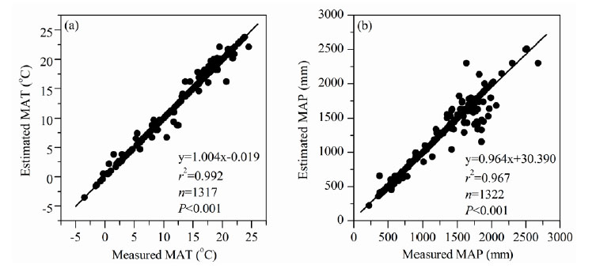

**Fig. 2.** Relationships between measured and estimated values for (a) mean annual temperature (MAT), and (b) mean annual precipitation (MAP). Solid lines denote regression lines.

**(d) Soil fertility levels:** Soil fertility levels were determined by extracting background values of soil organic matter content using geographical coordinates from a 30 arc-seconds resolution soil database of China (Shangguan et al. 2013; http://globalchange.bnu.edu.cn/research/soil2). Soil fertility was categorized into five levels based on soil organic matter background values (in increasing order): (I) ≤ 1.0 g/100g, (II) 1.0-2.0 g/100g, (III) 2.0-3.0 g/100g, (IV) 3.0-4.0 g/100g, and (V) ≥ 4.0 g/100g. An investigator should consider whether our resolutions meet the needs of his studies when applying site soil fertility levels.

**(5) Project personnel:** Same as authors.

Class III. Data set status and accessibility

**A. Status**

**(1) Latest update:** This version of comprehensive forest biomass data set of China was compiled from published studies during the 1978–2008 period. Data collection is ongoing, and the data set will be updated as data is collected and verified.

**(2) Latest archive data:** May 22, 2012

**(3) Metadata status:** The metadata are complete and up to date.

**(4) Data verification:** Duplicate and suspect data were verified carefully. If a measured value (e.g., biomass or necromass) was more (or less) than twice the value in a similar growth stage and site condition, it was considered suspect data. An expert rechecked all these forms of data to determine inclusion in our dataset.

**B. Accessibility**

**(1) Storage location and medium:** The data set is stored on three originators' (X. Wang, X. Zhang and Y. Luo) computer hard drives, and in the Ecological Society of America's Ecological Archives.

**(2) Contact persons:**

Xiaoke Wang, email: wangxk@rcees.ac.cn, Tel. & Fax: 86-10-62943822. State Key Laboratory of Urban and Regional Ecology, Research Center for Eco-Environmental Sciences, Chinese Academy of Sciences, 18 Shuangqing Road, Haidian District, Beijing 100085, China;

Xiaoquan Zhang, email: zxiaoquan@tnc.org, Tel.: 86-10-85319588, Fax: 86-10-85323922. The Nature Conservancy China Program, 9 Jianguomenwai Avenue, Chaoyang District, Beijing 100600, China;

Yunjian Luo, email: yunjianluo@gmail.com, Tel.: 86-592-6190750, Fax: 86-592-6190977. Key Laboratory of Urban Environment and Health, Institute of Urban Environment, Chinese Academy of Sciences, 1799 Jimei Avenue, Jimei District, Xiamen 361021, China.

**(3) Copyright restrictions:** None.

**(4) Proprietary restrictions:** None.

**(5) Costs:** None.

Class IV. Data structural descriptors

**A. Data set file**

**(1) Identity:** CForBioData_v1.0.txt

**(2) Size:** 1,607 entries, 458 kB.

**(3) Format and storage mode:** ASCII text, tab delimited. No compression schemes were used.

**(4) Header information:** The first row of the file contains the variable names in Table 2.

**(5) Alphanumeric attributes:** Mixed.

**(6) Special characters/fields:** All missing values are denoted as "NA".

**(7) Authentication procedures:** None.

**B. Variable information**

**Table 2. Variable information in our data set.**

[output not shown]

* In this study, primary and secondary forests were defined because these terms have varying usages in the literature. Primary forests are natural forest communities that occur naturally without significant disturbances (in the absence of natural disturbances, e.g., fire and insect pests; and anthropogenic disturbances, e.g., logging and pruning). Secondary forests are natural forest communities that regenerate after significant primary forest disturbances (in the presence of substantial natural and human disturbance regimes).

** In China, the age of a natural forest is generally defined as age since germination, and the age of a planted forest is defined as age since planting. Stand age is usually obtained from historical records, or counting tree rings from core samples of dominant tree species. Stand descriptions from original studies indicated that trees of all-ages represented some natural forests, i.e., trees of all age classes (young to mature or overmature), particularly primary forests. Therefore, stand age for these forests were denoted as 'All-aged' in the column 'Stand age' in our data set.

*** According to the descriptions of stand measurement, the vast majority of original studies measured all trees higher than breast height (1.3 m) within plots, and thus did not employ specified MMD values. In these studies MMD values actually referred to the minimum DBH of trees higher than breast height. Therefore, MMD values in these studies were denoted as 'Min DBH' in the column 'MMD' of our data set.

Class V. Supplemental descriptors

**A. Data acquisition**

**(1) Data forms:** The data form was prepared according to the order of variables provided in Table 2.

**(2) Location of completed data forms:** The completed data form is stored on three originators' (X. Wang, X. Zhang and Y. Luo) computer hard drives, and in the Ecological Society of America's Ecological Archives.

**(3) Data entry verification procedures:** See data verification description (Class III, Section A).

**B. QA/QC procedures:** See data verification description (Class III, Section A).

**C. Related material:** N/A.

**D. Computer programs and data processing algorithms:** N/A.

**E. Archiving:** N/A.

**F. Publications and results:** We have published three articles on China's biomass factors to quantify forest carbon dynamics using this dataset, i.e., root-shoot ratios (Luo et al. 2012), biomass expansion factors (Luo et al. 2013), and biomass conversion factors (Luo et al. 2014). In addition, we have been preparing articles on regional patterns of forest biomass and its allocation.

**G. History of data set usage:** See Section F above.

**(1) Data request history:** N/A.

**(2) Data set update history:** N/A.

**(3) Review history:** N/A.

**(4) Questions and comments from secondary users:** N/A.

Acknowledgments

The authors thank Dr. Hendrik Poorter (Forschungszentrum Jülich, Germany) and anonymous reviewers for their valuable comments. This work was supported by the Strategic Priority Program of Chinese Academy of Sciences (XDA05060102 and XDA05050602), Fujian Provincial S&T Program (2013Y0083), and Forestry Public Welfare Program of China (201304205).

Literature cited

Cannell, M.G.R. 1982. World Forest Biomass and Primary Production Data. Academic Press, London, UK.

Enquist, B.J., and K.J. Niklas. 2002. Global allocation rules for patterns of biomass partitioning in seed plants. Science 295: 1517-1520.

Feng, Z.W., X.K. Wang, and G. Wu. 1999. Biomass and Productivity of Forest Ecosystems in China. Science Press, Beijing, China. (In Chinese)

Hijmans, R.J., S.E. Cameron, J.L. Parra, P.G. Jones, and A. Jarvis. 2005. Very high resolution interpolated climate surfaces for global land areas. International Journal of Climatology 25: 1965-1978.

Houghton, R.A., F. Hall, and S.J. Goetz. 2009. Importance of biomass in the global carbon cycle. Journal of Geophysical Research 114: G00E03.

Keith, H., B.G. Mackey, and D.B. Lindenmayer. 2009. Re-evaluation of forest biomass carbon stocks and lessons from the world's most carbon-dense forests. Proceedings of the National Academy of Sciences USA, 106(28): 11635-11640.

Luo, T.X. 1996. Patterns of net primary productivity for Chinese major forest types and their mathematical models. Ph.D. dissertation, Commission for Integrated Survey of Natural Resources, Chinese Academy of Sciences, Beijing, China. (In Chinese with English abstract)

Luo, Y.J., X.K. Wang, X.Q. Zhang, T.H. Booth, and F. Lu. 2012. Root:shoot ratios across China's forests: Forest type and climatic effects. Forest Ecology and Management 269: 19-25.

Luo, Y.J., X.K. Wang, X.Q. Zhang, Y. Ren, and H. Poorter. 2013. Variation in biomass expansion factors for China's forests in relation to forest type, climate, and stand development. Annals of Forest Science 70: 589-599.

Luo, Y.J., X.Q. Zhang, X.K. Wang, and Y. Ren. 2014. Dissecting variation in biomass conversion factors across China's forests: Implications for biomass and carbon accounting. PLoS ONE, doi: 10.1371/journal.pone.0094777.

McCarthy, M.C., and B.J. Enquist. 2007. Consistency between an allometric approach and optimal partitioning theory in global patterns of plant biomass allocation. Functional Ecology 21: 713-720.

McCarthy, M.C., B.J. Enquist, and A.J. Kerkhoff. 2007. Organ partitioning and distribution across the seed plants: Assessing the relative importance of phylogeny and function. International Journal of Plant Science 168(5): 751-761.

Ni, J., X.S. Zhang, and M.O. Scurlock. 2001. Synthesis and analysis of biomass and net primary productivity in Chinese forests. Annals of Forest Science 58: 351-384.

Niklas, K.J., and B.J. Enquist. 2002. Canonical rules for plant organ biomass partitioning and annual allocation. American Journal of Botany 89(5): 812-819.

Pan, W.C., L.C. Li, Z.H. Gao, X.Q. Zhang, and D.Y. Tang. 1978. Study on the biomass and productivity of Chinese fir plantations. Hubei Forestry Science and Technology (5): 1-12.

Poorter, H., K.J. Niklas, P.B. Reich, J. Oleksyn, P. Poot, and L. Mommer. 2012. Biomass allocation to leaves, stems, and roots: Meta-analysis of interspecific variation and environmental control. New Phytologist 193: 30-50.

Shangguan, W., Y.J. Dai, B.Y. Liu, A.X. Zhu, Q.Y. Duan, L.Z. Wu, D.J. Ji, A.Z. Ye, H. Yuan, Q. Zhang, D.D. Chen, M. Chen, J.T. Chu, Y.J. Dou, J.X. Guo, H.Q. Li, J.J. Li, L. Liang, X. Liang, H.P. Liu, S.Y. Liu, C.Y. Miao, and Y.Z. Zhang. 2013. A China data set of soil properties for land surface modeling. Journal of Advances in Modeling Earth Systems 5: 1-13.

Teobaldelli, M., Z. Somogyi, M. Migliavacca, and V.A. Usoltsev. 2009. Generalized functions of biomass expansion factors for conifers and broadleaved by stand age, growing stock and site index. Forest Ecology and Management 257: 1004-1013.

Usoltsev, V.A. 2001. Forest Biomass of Northern Eurasia: Database and Geography. Russian Academy of Sciences, Ural Branch, Yekaterinburg, 706pp. (In Russian).

Wang, X.P., J.Y. Fang, and B. Zhu. 2008. Forest biomass and root-shoot allocation in northeast China. Forest Ecology and Management 255: 4007-4020.

West, P.W. 2009. Tree and Forest Measurement, 2nd Edition. Springer-Verlag, Berlin, 190pp.

Wu, Z.L. 1997. Forests in China (vol. 1): General Introduction. China Forestry Publishing House, Beijing, pp. 392-574.

Zhang, X.S. 2007. Vegetation Map of China and Its Geographic Patterns. Geological Publishing House, Beijing, pp. 91-124.

Zhou, G.S., Y.H. Wang, Y.L. Jiang, and Z.Y. Yang. 2002. Estimating biomass and net primary production from forest inventory data: A case study of China's *Larix* forests. Forest Ecology and Management 169: 149-157.

Zhu, S.Q., and S.Y. Yang. 1979. Preliminary study on the biomass and its distribution of *Cunninghamia lanceolata* plantation. Guizhou Agricultural College, Guiyang, pp. 1-14.

**Literature cited in the dataset**

Ai, X.R., and Z.K. Shen. 2001. Study on the growth and biomass of *Larix kaempferi* plantation. Journal of Hubei Institute for Nationalities (Natural Sciences) 19(2): 20-22.

Ai, X.R., and G.L. Zhou. 1996. Study on the biomass of Chinese fir plantation in the north boundary of middle subtropical zone. Hubei Forestry Science and Technology (2): 17-20.

An, H.P., X.L. Jin, and C.H. Yang. 1991. Study on the growth rhythm and biomass dynamics of the major vegetation types in Banqiaohe Watershed. Guizhou Forestry Science and Technology 19(4): 20-34.

Bai, J., Y.L. Tian, Z. Han, and L.S. Guo. 2008. Study on the relationships between aboveground biomass, leaf area index and stand density in *Pinus tabuliformis* artificial forest. Journal of Arid Land Resources and Environment 22(3): 183-187.

Bai, Y.Q., and H.Z. Zhan. 1980. Study on the biomass of *Larix gmelinii* plantation. Forest Investigation Design (1): 21-25.

Bao, C.S. 1991. Nutrient cycling in a birch forest. Pages 217-227 *in* X.F. Zhou, Y.H. Wang, and H.X. Zhao, editors. Long-term located research on forest ecosystems (vol. 1). Northeast Forestry University Press, Harbin, China.

Bao, X.C., L.Z. Chen, Q.L. Chen, J.K. Ren, Y.H. Hu, and Y. Li. 1984. The biomass of planted oriental oak (*Quercus variabilis*) forest. Acta Phytoecologica et Geobotanica Sinica 8(4): 313-320.

Bi, J., Z.W. Ma, Y.L. Xu, Z.Y. Wang, Z.H. Liu, and Y.Z. Wang. 2000. The community structure and biomass of *Platycladus orientalis* plantations. Journal of Northeast Forestry University 28(1): 13-15.

Cai, T.J., C.S. Li, B.W. Liu, and C.R. Wang. 1991. Study on the growth and productivity of *Phellodendron amurense* and *Pinus koraiensis* mixed stand. Journal of Northeast Forestry University 19(S): 331-336.

Cao, Z.W., Y.W. Dai, Y.Z. Zhang, Y. Gao, and D.L. Yan. 2006. Study on the productivity of poplar plantations in Nenjiang sandy land. Protection Forest Science and Technology (2): 9-11, 93.

Chai, B.F., J.T. Zhang, Y. Qiu, and F.Y. Zheng. 1999. Study on aboveground biomass and productivity of *Larix principis-rupprechtii* artificial forest in the west of Shanxi Province. Henan Science 17(S): 68-71.

Chang, X.X., K.J. Che, and C.F. Song. 1996. Preliminary study on the biomass of *Picea crassifolia* forests in Qilian Mountains. Journal of Northwest Forestry College 11(1): 19-23.

Chang, X.X., K.J. Che, C.F. Song, J.Y. Wang, and B.X. Li. 1997. Biomass and nutrient element accumulation of *Sabina prezewalskii* forest. Journal of Northwest Forestry College 12(1): 23-28.

Chen, A.L., G.S. Chen, J.S. Xie, and Y.S. Yang. 2000a. Biomass and nutrient distribution of tree rotation of Chinese fir and slender-stalk altingia. Journal of Zhejiang Forestry College 17(4): 369-372.

Chen, B.G., J.L. Huang, S.Y. Lin, and R.H. Zheng. 1995. Influence on the growth of *Eucalyptus leizhouensis* No. 1 stands by interplanting *Ananas comosus*. Pages 201-207 *in* T.X. Zeng, editor. Studies on the *Eucalypts* ecosystem of short rotation in Leizhou. China Forestry Publishing House, Beijing, China.

Chen, B.H., and C.Y. Chen. 1980. A preliminary study on the biomass and productivity of *Picea koraiensis* forests in the dunes. Scientia Silvae Sinicae (4): 269-278.

Chen, C.F. 1996. Study on the aboveground biomass of evergreen broadleaved forests in Jiangxi Province. Jiangxi Forestry Science and Technology (2): 1-4.

Chen, C.G. 1984. Studies on the productivity of *Pinus armandii* forests in Qinling Mountains: (1) Biomass and productivity of tree layers in *Pinus armandii* forests. Journal of Northwestern College of Forestry (1): 1-18.

Chen, C.G., L.Q. Gong, H. Peng, and X.Z. Liu. 1996a. Biomass and productivity of the sharptooth oak forests in Qinling Mountains. Journal of Northwest Forestry College 11(S): 103-114.

Chen, C.G., and H. Peng. 1996. Standing crops and productivity of the major forest types at Huoditang Forest Region of Qinling Mountains. Journal of Northwest Forestry College 11(S): 92-102.

Chen, D.K., X.F. Zhou, H.X. Zhao, Y.H. Wang, and Y.Y. Jin. 1982. Study on the structure, function and succession of four natural secondary forests. Journal of Northeastern Forestry Institute (2): 1-20.

Chen, D.Q. 2001. The growth and soil amelioration of mixed plantation of *Fokienia hodginsii* and *Schima superba*. China Forestry Science and Technology 15(3): 24-26.

Chen, G.R. 2005. Comparative study between first generation artificially regenerated *Castanopsis carlesii* forests and second generation ones. East China Forest Management 19(4): 13-18.

Chen, G.S., Y.S. Yang, J.S. Xie, J.F. Guo, R. Gao, and W. Qian. 2005a. Conversion of a natural broadleaved evergreen forest into pure plantation forests in a subtropical area: Effects on carbon storage. Annals of Forest Science 62: 659-668.

Chen, H.J. 1998. Biomass and nutrient distribution in a Chinese fir plantation chronosequence in southwest Hunan, China. Forest Ecology and Management 105: 209-216.

Chen, H.W., X. Feng, Y.G. Liu, Y. Zhou, D.M. Wang, L.F. Li, and M. Meng. 2002. Study on the biomass of six young plantations in Xishuangbanna. Yunnan Forestry Science and Technology (3): 19-22.

Chen, J.H. 2006a. Study on the biomass of *Fokienia hodginsii* *f. columnaris* plantation. Fujian Agricultural Science and Technology (4): 61-63.

Chen, J.Z. 2006b. Study on mixed plantation of *Cunninghamia lanceolata* and *Sassafras tzumu* in the mountainous region of the north Fujian Province. Science and Technology of Qinghai Agriculture and Forestry (2): 83-86.

Chen, L.G., J.N. Lian, W. Hong, Y.S. Zheng, K.W. Chen, and H.Z. Yang. 2000b. Evaluation on silvicultural effects of mixed forests of Chinese fir and *Phyllostachys heterocycla* cv. *pubescens*. Journal of Fujian College of Forestry 20(4): 309-312.

Chen, L.N., Y. Xiao, Q. Gai, and W.X. Ji. 1991. Preliminary study on the biomass of *Larix principis-rupprechtii* forest in Pangquangou Nature Reserve: Community structure, biomass and net primary productivity. Journal of Shanxi Agricultural University 11(3): 240-247.

Chen, L.Z., Q.L. Chen, X.C. Bao, J.K. Ren, Y.G. Miao, and Y.H. Hu. 1986a. Study on Chinese arborvitae (*Platycladus orientalis*) forest and its biomass in Beijing. Acta Phytoecologica et Geobotanica Sinica 10(1): 17-25.

Chen, L.Z., J.K. Ren, X.C. Bao, Q.L. Chen, Y.H. Hu, Y.G. Miao, and Y. Li. 1984. Study on the community characteristics and the biomass of Chinese pine plantation in Xishan Region, Beijing. Acta Phytoecologica et Geobotanica Sinica 8(3): 173-181.

Chen, L.Z., J.K. Ren, Q.L. Chen, Y.H. Hu, X.C. Bao, and Y.G. Miao. 1986b. Study on the biomass of *Robinia pseudoacacia* plantation in Xishan Region, Beijing. Acta Botanica Sinica 28(2): 201-208.

Chen, Q.C. 1993. Primary Productivity of an Evergreen Broadleaved Forest Ecosystem. Hangzhou University Press, Hangzhou, China.

Chen, T., Y.G. Wen, Y.P. Sun, and H.W. Liang. 2005b. Preliminary study on the biomass and productivity of *Eucalyptus urophylla* × *E. grandis* plantations with successive rotations. Guangxi Forestry Science 34(1): 8-12.

Chen, W.R. 2000. Study on the dynamics of aboveground net productivity of *Alniphyllum fortune* plantation. Journal of Fujian Forestry Science and Technology 27(3): 31-34, 74.

Chen, X.Q., P.Y. Zhu, and K. Segawa. 1994. Study on standing crop and its distribution of 30-year-old *Pinus massoniana* stands with various stand densities. Journal of Fujian Forestry Science and Technology 21(2): 19-23.

Chen, X.Y., Y.Y. Peng, C.J. Zhang, and J.H. Li. 1996b. Comparative study of the biomass and productivity of two forest communities in the subtropical zone. Journal of Central-South Forestry University 16(1): 1-7.

Chen, Y. 2006c. Study on the growth characteristics of *Castanopsis fissa* plantation in purple soils. Journal of Jiangsu Forestry Science and Technology 33(4): 23-24, 49.

Chen, Z.H., H.D. Zhang, B.S. Wang, and Z.Q. Zhang. 1993. Study on the biomass and allocation of an evergreen broadleaved forest in Heishiding, Guangdong. Acta Phytoecologica et Geobotanica Sinica 17(4): 289-298.

Chen, Z.J., J.Z. Zhang, J. Chen, Y.F. Xia, and S.Q. Huang. 1998. Preliminary study on the aboveground biomass of air-seeding *Pinus massoniana* forest. East China Forest Management 12(4): 51-53.

Chen, Z.M., Y.S. Zheng, X.H. Huang, S.F. Wang, L.S. Dong, and L.G. Chen. 2001a. Study on the biomass and its distribution of mixed forests of *Taiwania flousiana*. Journal of Fujian College of Forestry 21(2): 113-115.

Chen, Z.X., Y.J. He, F.M. Bai, J.H. Zhang, Z.H. Li. 2001b. Effects of stand density on the biomass and productivity of *Pinus massoniana* air-seeding stands. Journal of Central South Forestry University 21(1): 44-47.

Cheng, T.R., Q.Y. Ma, Z.K. Feng, and X. Luo. 2007. Study on forest biomass in Xiaolong Mountains, Gansu Province. Journal of Beijing Forestry University 29(1): 31-36.

Cheng, Z.Y., S.H. Fan, W.M. Cai, Y.B. Liu, X.T. Yu, G.F. Shen, and W.T. Sheng. 1996. Study on the biomass of Chinese fir plantation under different site conditions and stand ages: (3) The biomass accumulation of forest floor. Forest Research 9(M): 92-95.

Cui, L.J., Z.S. Liang, R.L. Han, and J.W. Yang. 2003. Biomass, soil and root system distribution characteristics of seabuckthorn × poplar mixed forest. Scientia Silvae Sinicae 39(6): 1-7.

Dai, H.Y., Q.L. Zhang, Q. Wei, and X. Guo. 2008. Study on effects of density on biomass allocation pattern in different forests. Journal of Anhui Agricultural Sciences 36(11): 4514-4516.

Dang, C.L., and Z.L. Wu. 1991. Study on the biomass of *Pinus yunnanensis* forest. Acta Botanica Yunnanica 13(1): 59-64.

Dang, C.L., and Z.L. Wu. 1992. Study on the biomass of a monsoon evergreen broadleaved forest dominated by *Castanopsis echidnocarpa*. Journal of Yunnan University (Natural Sciences) 14(2): 95-107.

Dang, C.L., and Z.L. Wu. 1994. Study on the biomass of *Castanopsis orthacantha* community. Journal of Yunnan University (Natural Sciences) 16(3): 195-199.

Dang, C.L., Z.L. Wu, C.Y. Wang, Z.R. He, and Z.F. Gu. 1994a. Study on the biomass and net primary productivity of *Abies georgei* community. Journal of Yunnan University (Natural Sciences) 16(3): 214-219.

Dang, C.L., Z.L. Wu, and Q. Zhang. 1997. Study on the biomass of the ravine tropical rain forest in Xishuangbanna. Acta Botanica Yunnanica (S8): 123-128.

Dang, C.L., Z.L. Wu, and Z. Zhang. 1994b. Study on the biomass of *Cyclobalanopsis delavayi* community. Journal of Yunnan University (Natural Sciences) 16(3): 205-209.

Deng, R.W., T.X. Chen, and Y.M. Feng. 1985. Study on the light utilization and the biomass in the tropical artificial forests. Acta Ecologica Sinica 5(3): 231-240.

Deng, S.J., L.P. Liao, S.L. Wang, H. Gao, and B. Lin. 2000. Bioproductivity of *Castanopsis hysrix - Cyclobalanopsis glauca - Machilus pauhoi* community in Huitong, Hunan. Chinese Journal of Applied Ecology 11(5): 651-654.

Deng, S.J., K.P. Wang, and H. Gao. 1988. Biological productivity and nutrient distribution in overmature plantation of *Cunninghamia lanceolata*. Chinese Journal of Ecology 7(1): 13-18.

Di, D.S., H.Z. Liao, C.N. Zhang, and Z.Z. Chen. 1991. A study on ecosystem productivity and tree growth of *Ormosia xylocarpa* plantations. Journal of Nanjing Forestry University 15(3): 60-65.

Ding, B.Y., S.R. Liu, and T.J. Cai. 1990. Study on biological productivity of artificial forests of Dahurian larches. Acta Phytoecologica et Geobotanica Sinica 14(3): 226-236.

Ding, B.Y., and J.H. Sun. 1989. Study on biological productivity and nutrient cycling of artificial forest ecosystem of Korean pine. Journal of Northeast Forestry University 17(S): 1-98.

Ding, G.J. 2000. Study on changes in the biomass and productivity of Masson pine plantations: (3) Biomass and productivity of stands under different sites. Journal of Mountain Agriculture and Biology 19(6): 411-417.

Ding, G.J. 2003. Study on changes in the biomass and productivity of Masson pine plantations: (1) Effects of planting densities on the biomass. Journal of Fujian College of Forestry 23(1): 34-38.

Ding, G.J., and P.C. Wang. 2001. Study on changes in the biomass and productivity of Masson pine plantations: (2) Biomass and productivity of stands at different ages. Forest Research 15(1): 54-60.

Dong, S.R., and Y.X. Guan. 1980. Study on the productivity of *Pinus tabuliformis* stands in Taiyue Mountain, Shanxi Province. Journal of Beijing Forestry College (1): 1-20.

Dong, Z.B. 2000. Study on root system and the biomass of mixed plantation of *Pinus massoniana* and *Eucommia ulmoides*. Journal of Chuzhou Normal College 2(4): 95-97, 80.

Du, G.J., L.X. Hong, and G.X. Yao. 1987. Study on the aboveground biomass of major evergreen broadleaved secondary forests in the northwest of Zhejiang Province. Journal of Zhejiang Forestry Science and Technology 7(5): 5-12.

Fan, H.B., Y.Y. Li, B.Q. Su, D.X. Lin, C.H. Liu, and Z.K. Jiang. 2006. Allocation patterns of the biomass and productivity in the mixed uneven-aged stands of Masson pine and hardwood species. Acta Ecologica Sinica 26(8): 2463-2473.

Fan, H.B., Y.Y. Li, X. Sun, and D.X. Lin. 2005. Litter accumulation and nutrient fluxes in *Pinus massoniana* stand and its mixed forests with broadleaved trees. Chinese Journal of Applied and Environmental Biology 11(5): 521-527.

Fan, S.H., W.T. Sheng, Y.B. Liu, L.X. Zheng, P.S. Liu, X.T. Yu, and G.F. Shen. 1996a. Study on the growth of Chinese fir plantation under different site conditions and stand ages. Forest Research 9(M): 50-54.

Fan, S.H., X.T. Yu, Z.T. Chen, P.S. Liu, Z.Y. He, G.F. Shen, and W.T. Sheng. 1996b. Study on the biomass of Chinese fir plantation under different site conditions and stand ages: (1) The biomass accumulation of stands. Forest Research 9(M): 78-85.

Fan, Z.F., Y.T. An, and X.H. Zhao. 1997. Study on the biomass and productivity of *Pinus tabuliformis* plantations. Journal of Beijing Forestry University 19(S2): 93-98.

Fang, C.L., X.W. Zhu, and H.C. Zhang. 1991. Preliminary study on the biomass and productivity of *Picea crassifolia* natural secondary forests. Journal of Qinghai University 9(1): 71-77.

Fang, H., and F.B. Kong. 2003. Study on the biomass and its allocation of Loblolly pine plantations with different stand densities. Journal of Fujian College of Forestry 23(2): 182-185.

Fang, H.B., D.L. Tian, and W.X. Kang. 1999. Dynamics of the biomass of a thinned Chinese fir plantation ecosystem. Journal of Central South Forestry University 19(1): 16-19.

Fang, J.P., and W.H. Xiang. 2008. Biomass and its distribution of a primeval *Abies georgei* var. *smithii* forest in Sejila Mountain of Tibet Plateau. Scientia Silvae Sinicae 44(5): 17-23.

Fang, Q. 1990. Effects of soil and floor plants management on energy utilization and nutrient cycles of *Cunninghamia lanceolata* plantation. Scientia Silvae Sinicae 26(3): 201-208.

Fang, S.Z., S.Z. Cao, J.H. Chen, B. Yang, X.F. Ding, and Z.Y. Song. 1995. Study on the biomass and pulp-making performance of *Metasequoia glyptostroboides* plantation. Journal of Nanjing Forestry University 19(4): 51-56.

Fang, S.Z., X.Z. Xu, S.X. Lü, L.Z. Tang, and F.L. Cao. 1998. Leaf area index and the productivity of mid- and short-rotation poplar plantations for pulp-timber making. Chinese Journal of Applied Ecology 9(3): 225-230.

Fang, X., and D.L. Tian. 2006. Dynamic of carbon stock and carbon sequestration in Chinese fir plantation. Guihaia 26(5): 516-522.

Fang, X., D.L. Tian, and W.H. Xiang. 2002. Carbon density, storage and distribution of Chinese fir plantation at the fast-growing stage. Scientia Silvae Sinicae 38(3): 14-19.

Fang, X., D.L. Tian, W.H. Xiang, and B.Y. Cai. 2003a. Carbon accumulation and its distribution of slash pine plantations with different stand densities. Journal of Zhejiang Forestry College 20(4): 374-379.

Fang, X., D.L. Tian, and C.H. Xu. 2003b. The productivity and carbon dynamics of Masson pine plantation. Journal of Central South Forestry University 23(2): 11-15.

Feng, L., and Y.G. Yang. 1981. Study on the biomass of natural secondary forests of *Pinus tabuliformis*, *Betula platyphylla* and *Populus davidiana* in Inner Mongolia Region. Journal of Inner Mongolia Forestry College (3): 1-17.

Feng, L., and Y.G. Yang. 1985. A study on biomass and productivity of three Dahurian larch virgin forests. Scientia Silvae Sinicae 21(1): 86-92.

Feng, Z.L., J.W. Tang, Z. Zheng, Q.S. Song, M. Cao, J.H. Zhang, and J.W. Xie. 1999. Biomass dynamics of the pioneer *Trema orientalis* community in the early stages of secondary succession of tropical forest in Xishuangbanna. Chinese Journal of Ecology 18(5): 1-6.

Feng, Z.L., Z. Zheng, J.W. Tang, Q.S. Song, and J.H. Zhang. 2005. Biomass of tropical secondary *Mallotus paniculatus* forest in Xishuangbanna. Chinese Journal of Ecology 24(3): 238-242.

Feng, Z.W. 1980. Study on the biomass of *Cunninghamia lanceolata* plantations. Pages 322-333 *in* Taoyuan Agricultural Experiment Station of Chinese Academy of Sciences, editor. Comprehensive investigation reports of Taoyuan County. Hunan Science and Technology Press, Changsha, China.

Feng, Z.W., C.Y. Chen, C.H. Li, G.H. Xu, and C.L. Zhou. 1982a. Relationships between the growth development and environment of *Cunninghamia lanceolata* plantation in Huitong, Hunan Province. Journal of Nanjing Technological College of Forest Products (3): 19-38.

Feng, Z.W., C.Y. Chen, J.W. Zhang, K.P. Wang, J.L. Zhao, and H. Gao. 1982b. Study on the biomass of *Pinus massoniana* stand in Huitong County, Hunan Province. Scientia Silvae Sinicae 18(2): 127-134.

Feng, Z.W., C.Y. Chen, J.W. Zhang, J.L. Zhao, K.P. Wang, and S.Y. Zeng. 1984. The biological productivity of Chinese fir stands at different zones. Acta Phytoecologica et Geobotanica Sinica 8(2): 93-100.

Feng, Z.W., J.W. Zhang, C.Y. Chen, K.P. Wang, J.L. Zhao, S.Y. Zeng, and J.X. Ma. 1983. Biological productivity and nutrient distribution in artificial *Michelia macclurei* stand. Journal of Northeastern Forestry Institute 11(2): 13-20.

Fu, J.H. 1989. Contents, accumulation and biocycle of micronutrients in a Chinese fir plantation. Journal of Central South Forestry University 9(S): 76-84.

Fu, Y.S., W.Y. Guo, and S. Ai. 1992. Study on the community composition and biomass of *Pinus massoniana* plantation in Dawu County, Hubei Province. Journal of Hubei University (Natural Sciences) 14(2): 178-182.

Fu, Z.J. 1994a. Study on synecological features and biomass of *Larix chinensis* forest in Taibai Mountain. Journal of Hanzhong Teachers College (Natural Sciences) (2): 69-72.

Fu, Z.J. 1994b. Study on synecological features and biomass of *Betula albo-sinensis* forest in Taibai Mountain. Journal of Yan'an University (Natural Sciences) 13(2): 37-40.

Gao, J.R., and B. Xiao. 2001. Nutrient distribution and accumulation pattern of Chinese pine plantations in Qiaoshan forested region. Chinese Journal of Applied Ecology 12(5): 667-671.

Gao, J.R., D.S. Zhang, B. Xiao, and J.Z. Niu. 2002. Nutrient distribution and accumulation pattern of Chinese pine plantation ecosystems in the loess region. Journal of Beijing Forestry University 24(1): 26-30.

Gao, Z.H. 1986. Preliminary study on the biomass of Chinese fir plantations with different management intensities. Journal of Zhejiang Forestry Science and Technology (2): 25-30.

Gao, Z.H., G.H. Jiang, A.J. Xing, and M.R. Yu. 1992. A study on the biomass of *Metasequoia glyptostroboides* plantation in Zhebei Plain. Acta Phytoecologica et Geobotanica Sinica 16(1): 64-71.

Gu, Y.K., B.G. Chen, and Y.H. Feng. 1987. An investigation on the aboveground biomass and productivity of artificial *Cunninghamia lanceolata* stands in Xijiang Region, Guangdong Province. Journal of South China Agricultural University 8(1): 41-50.

Guan, D.S. 1986. The biomass and productivity of four stands in the forest area of Liuxihe Reservoir. Ecologic Science (2): 45-52.

Guan, H.S., and Y.L. Liu. 1993. Study on the biomass of poplar plantations in the middle region of "One River and Two Streams" Watershed, Tibet. Forest Science and Technology (9): 20-22, 32.

Guo, C.Y., J. Wu, Y.L. Tian, and L.S. Guo. 2006. A study on the biomass of *Pinus tabuliformis* plantations with different stand densities in Daqing Mountain. Journal of Inner Mongolia Agricultural University 27(3): 29-33.

Guo, D.W., X.Q. Chen, G.J. Li, N.Q. Chen, and Z.H. Yu. 1991. Study on the mixed forest of *Pinus koraiensis* and *Fraxinus mandshurica*: (1) The comprehensive effects of mixed forest and its community stability. Journal of Northeast Forestry University 19(S): 121-129.

Guo, M.L. 2006. Study on the growth characteristics of young *Eucalyptus* plantations under different tending types. East China Forest Management 20(3): 24-26.

Guo, R.H., G.F. Ye, C.Y. Lu, S.S. Xiao, and Y.L. Li. 2008. Carbon storage and its distribution of the tree layer in the mixed plantation of *Casuarina equisetifolia* and *Pinus elliottii*. Straits Science (10): 24-25, 36.

Guo, Y.L. 2003. Study on the growth of mixed Chinese fir and *Altingia gracilipes* plantation. China Forestry Science and Technology 17(S): 28-30.

Guo, Z.J., X.D. Song, and H.G. Zhao. 2007. Biomass, soil characteristics and root systems of *Hippophae rhamnoides* and *Platycladus orientalis* mixed forest. Bulletin of Soil and Water Conservation 27(3): 18-23.

Han, E.X., G. Han, and Y.S. Bo. 2007a. Study on the growth and soil properties of *Pinus tabuliformis*, *Platycladus orientalis* and *Hippophae rhamnoides* mixed plantation in the Loess Plateau. Journal of Northwest Forestry University 22(3): 100-104.

Han, G.J., G.L. Cong, and H.L. Shen. 2007b. Heating value and energy structure of *Pinus sylvestris* var. *mongolica* plantation: (1) The biomass, heating value, energy pattern and distribution of tree and understory vegetation. Journal of Northeast Forestry University 35(6): 21-23, 33.

Han, M.Z. 1994. A study on the biomass and net primary productivity of a Dahurian larch-birch forest ecosystem. Pages 451-458 *in* Department of Science and Technology, Ministry of Forestry, editor. Long-term research on China's forest ecosystems. Northeast Forestry University Press, Harbin, China.

Han, Y.Z., Y.E. Li, S.F. Liang, and H.Y. Li. 1997. Study on the tree biomass of *Larix principis-rupprechtii* plantation. Journal of Shanxi Agricultural University 17(3): 278-283.

Han, Y.Z., and S.F. Liang. 1997. Study on the tree root system and its biomass of *Larix principis-rupprechtii* plantation. Shanxi Forestry Science and Technology (3): 36-40.

He, B., H.L. Diao, H.C. Huang, C.B. Huang, H.Z. Huang, and M.B. Wei. 2008. Dynamics of the biomass and productivity of *Taiwania flousiana* plantation. Journal of Northeast Forestry University 36(9): 17-18, 27.

He, G.P., Y.T. Chen, B.T. Hu, J.W. Feng, H.T. Liu, and H.M. Cai. 2001. Study on the biomass and soil fertility of pure and mixed stands of *Cunninghamia lanceolata*, *Liriodendron chinense* and *Sassafras tzumu*. Forest Research 14(5): 540-547.

He, G.P., Y.T. Chen, Y.H. Yu, H.T. Liu, and H.M. Cai. 2003. A study on the biomass of pure and mixed stands of *Elacocarpus sylvestris* and Chinese fir. Acta Agriculturae Universitatis Jiangxiensis 25(6): 819-823.

He, G.P., Y.T. Chen, Y.H. Yu, H.T. Liu, H.M. Cai, and Y.Z. Chen. 2004. Study on early growth characteristics of *Choerospondias axillaris* and *Cunninghamia lanceolata* mixed stand. Forest Research 17(2): 206-212.

He, L.X. 1998. Comparative study on the productivity and soil fertility of two forested stands in Central Hunan's hilly county. Journal of Central South Forestry University 18(1): 53-59.

Hu, D.L., Z.H. Li, and X.D. Xie. 1998. Study on the biomass and productivity of *Pinus taiwanensis* plantation. Journal of Central South Forestry University 18(1): 60-64.

Hu, W.L., X.R. Tan, F. Zhang, S.L. Wang, and Z.L. Wang. 1999. Effects of thinning on the biomass of *Pinus koraiensis* plantations. Journal of Liaoning Forestry Science and Technology (2): 13-16, 49.

Hu, X.S., X.S. Song, W. Hong, and C.Z. Wu. 2008. Energy storage and distribution of *Pinus massoniana* plantations at different ages. Journal of Fujian College of Forestry 28(3): 208-211.

Huang, C. 2002. The productivity and its distribution of 5-year-old *Pinus massoniana* forest on different site conditions. Journal of Fujian Forestry Science and Technology 29(4): 17-19, 71.

Huang, C.B., and H.W. Liang. 1998. The growth rhythm and biomass of young *Pinus massoniana* plantation in the southeast Guangxi. Journal of Guangxi Academy of Sciences 14(1): 22-27.

Huang, D.C. 1986. Study on the biomass of *Cryptomeria fortunei* plantation. Journal of Southwestern Forestry College (1): 23-28.

Huang, D.Z. 2006a. Biomass characteristics of secondary forest community of *Cyclobalanopsis chungii* in the lower Minjiang River. Protection Forest Science and Technology (1): 16-18.

Huang, J.H. 1985. Effects of thinning on the biomass and leaf area of Chinese fir plantation. Journal of Fujian Forestry Science and Technology (1): 59-62.

Huang, Q., Y.D. Li, J.Z. Lai, and G.J. Peng. 1991. Study on biomass of tropical mountain rain forest in Limushan, Hainan Island. Acta Phytoecologica et Geobotanica Sinica 15(3): 197-206.

Huang, Q.L., Y.H. Li, J.S. Huang, X.J. Zhu, and X.S. Lai. 1992. Study on the artificially-promoting fast-growing and high-yield broadleaved forests. Journal of Fujian College of Forestry 12(1): 116-120.

Huang, Q.N. 1998. Study on the growth law and biomass of *Castanopsis hystrix* natural forest. Journal of Fujian Forestry Science and Technology 25(2): 20-23.

Huang, S.S., H.R. Han, and Q.Y. Ma. 1999. Study on the biomass of broadleaved tree species in Taiyue Forest Region. Pages 96-102 *in* Z.H. Zhu, and J.C. Luo, editors. Forum of forest ecology (vol. 1). China Agricultural Science and Technology Press, Beijing, China.

Huang, T., Q.P. Zhong, and X.Y. Peng. 2000. Study on the biomass and productivity of *Liriodendron chinense* plantation. Jiangxi Forestry Science and Technology (5): 4-9.

Huang, W.C., and L.L. Huang. 2004. Study on effects of the mixed plantation of *Pinus massoniana* and *Schima superba*. Forest Research 17(3): 316-320.

Huang, X.H. 1988. Biomass, nutrient element storage and their distribution of Chinese fir plantation in Xijiang Region. Central South Forest Inventory and Planning (1): 13-21.

Huang, Y.L. 2006b. Comparison of growth and biomass productivity of mixed and pure forests of *Liquidambar formosana*. Journal of Southwest Forestry College 26(2): 15-18.

Huang, Y.Z., Z.X. Li, X.D. Li, W.M. Yang, Z.Y. Liang, H.F. Li, D.L. Liu, and B.S. Lu. 2007. Effects of acid deposition and atmospheric pollution on forest ecosystem biomass in southern China. Ecology and Environment 16(1): 60-65.

Huang, Z.Z., and J. Bi. 1992. Study on the biomass of *Robinia pseudoacacia* stands in Taihang Mountains. Journal of Hebei Forestry Science and Technology (2): 48-52.

Hui, G.Y., Y.W. Luo, and X.L. Zhang. 1989. A study on the productivity of Chinese fir (*Cunninghamia lanceolata*) plantation at hilly area in Dagang Mountain, Jiangxi Province. Scientia Silvae Sinicae 25(6): 564-569.

Hui, G.Y., S.Z. Tong, J.F. Liu, and Y.W. Luo. 1988. Study on the afforestation density of *Cunninghamia lanceolata*: (1) Effect of density on the biomass of young *C. lanceolata*. Forest Research 1(4): 413-417.

Jia, Y., and F. Zhang. 1985. Study on the biomass of *Pinus koraiensis* plantation in Caohekou Forest Region, Liaoning Province. Journal of Liaoning Forestry Science and Technology (5): 18-23.

Jiang, B., W.G. Yuan, G.Q. Zhu, J.T. Shi, P.F. Zhao, and Z.W. Xu. 1992. A preliminary study on the biomass and productivity of *Pinus massoniana*, *P. elliottii* and *P. taeda* plantations. Journal of Zhejiang Forestry Science and Technology 12(5): 1-8, 22.

Jiang, H. 1986. A study on the biomass and productivity of *Picea purpurea* natural forest. Acta Phytoecologica et Geobotanica Sinica 10(2): 146-152.

Jiang, H., and H.R. Lin. 1985. Study on the biomass and productivity of *Pinus yunnanensis* air-seeding forests. Journal of Sichuan Forestry Science and Technology (4): 1-10.

Jiang, H., and J.J. Zhu. 1986. Study on the biomass and productivity of *Picea asperata* natural forest. Journal of Sichuan Forestry Science and Technology 7(2): 5-13.

Jiang, X.Q. 1998. Study on the structure and productivity of the 17-year-old *Castanopsis carlesii* stand by artificial-promoting regeneration. Journal of Fujian College of Forestry 18(3): 263-266.

Jiang, Z.L., and S. Zhao. 1992. Study on the biomass of Loblolly pine plantation. Pages 10-15 *in* Z.L. Jiang, editor. Proceedings of forest ecosystems on Xiashu Ecological Station. China Forestry Publishing House, Beijing, China.

Jiao, S.R. 1984. Biomass and nutrient element distribution of *Pinus sylvestris* var. *mongolica* plantation in Zhanggutai Region Journal of Liaoning Forestry Science and Technology (5): 20-24, 37.

Jiao, S.R. 1985. A preliminary study of the biomass and nutrient element distribution in *Pinus sylvestris* var. *mongolica* plantations in Zhanggutai Region, Liaoning Province. Acta Phytoecologica et Geobotanica Sinica 9(4): 257-265.

Jie, J.L., Y.S. Zhan, W.C. Huang, W. Long, Y.C. Luo, H.Y. Hu, and Z.R. Xie. 2002. Study on the biomass of *Pinus elliottii* stand near Jinggangshan Line of Jing-Jiu Railway. Jiangxi Forestry Science and Technology (2): 17-20.

Kang, B., S.R. Liu, G.J. Zhang, J.G. Chang, Y.G. Wen, J.M. Ma, and W.F. Hao. 2006. Carbon accumulation and distribution in *Pinus massoniana* and *Cunninghamia lanceolata* mixed forest ecosystem in Daqingshan, Guangxi of China. Acta Ecologica Sinica 26(5): 1320-1329.

Kang, W.X., and H.B. Fang. 1997. Study on the energy storage and its distribution of Chinese fir plantations. Scientia Silvae Sinicae 33(S2): 67-73.

Kang, W.X., D.L. Tian, W.D. Yan, and X. Fang. 2004. Solar energy storage and distribution in bole stage of Chinese fir plantation. Scientia Silvae Sinicae 40(5): 205-209.

Lai, D., K.M. Lin, X.Y. Chen, J.S. Wang, and D.Z. Zhao. 2004a. Cuttage afforestations and their effects of *Pinus taeda*, *P. elliottii* and *P. massoniana*. Journal of Fujian Forestry Science and Technology 31(1): 21-25, 30.

Lai, D., K.M. Lin, J.S. Wang, X.Y. Chen, and D.Z. Zhao. 2004b. Cuttage afforestations and their effects of Masson pine. Forest Research 17(4): 434-440.

Li, C.S., and S.M. Chen. 1996. Study on the biomass and productivity of *Pinus thunbergii* plantation. Journal of Shandong Forestry Science and Technology (2): 44-45.

Li, D.H., X.B. Yang, and Q.S. Wu. 2007a. Comparative study on Cu accumulation and cycle in different *Eucalyptus* plantations. Journal of Soil and Water Conservation 21(5): 59-63.

Li, G.X., G.T. Meng, X.J. Fang, N.J. Lang, C.M. Yuan, and S.L. Wen. 2006a. Characteristics and biomass of *Alnus cremastogyne* plantation community in central Yunnan Plateau. Journal of Zhejiang Forestry College 23(4): 362-366.

Li, J.F., Y.B. Gong, L.W. Chen, Y.Z. Cheng, and F.H. Zhang. 2007b. Spatial pattern of the biomass and phosphorus element in three types of stands in Guangyuan City. Journal of Sichuan Forestry Science and Technology 28(5): 36-40.

Li, J.L., S.C. Liang, and S.Z. Cheng. 1997. Preliminary study on the biomass models of *Keteleeria davidiana* var. *chien-peii* population in Qingyan Town, Guizhou Province. Journal of Guizhou Normal University (Natural Sciences) 15(1): 7-12.

Li, L.H. 2002. Study on the growth and biomass of *Cunninghamia lanceolata* and *Tsoongiodendron odorum* mixed forests. Journal of Fujian Forestry Science and Technology 29(1): 6-8, 13.

Li, S.C., X.L. Liu, X.Q. Liu, and Y.H. Shi. 1995a. Study on the biomass and hydrological effects of *Pinus massoniana* plantation. Central South Forest Inventory and Planning (3): 26-29.

Li, S.H., J.N. Shi, and M.Q. Wu. 2007c. Biomass and vertical distribution of the second-rotation Chinese fir plantation. Forest Engineering 23(1): 1-4.

Li, S.Q. 2007. Study on biomass allocation pattern of 22-year-old *Pinus massoniana* plantation. Fujian Agricultural Science and Technology (4): 76-77.

Li, X.C., L.B. Huang, G.R. Gui, Z.J. Li, K.S. Fan, H.L. Lu, X.X. Du, W.M. Ma, J.M. Yang, and Y.L. Li. 1996a. Study on the effects of initially-planted density of young Chinese fir plantation for construction timber. Journal of Jiangsu Forestry Science and Technology 23(3): 1-6.

Li, X.D. 1984. Preliminary study on the biomass and nutrient element distribution of *Michelia macclurel* plantation in different site conditions. Journal of Guangxi Agricultural College (2): 88-100.

Li, X.G., J.Y. Xu, and C.Y. Qu. 1988. Study on the biomass of *Gordonia acumenata* community in Jinyun Mountains. Pages 234-250 *in* Z.C. Zhong, editor. Ecological research on evergreen broadleaved forests. Southwest Normal University Press, Chongqing, China.

Li, X.R., Q.J. Liu, Y.R. Chen, L.L. Hu, and F.T. Yang. 2006b. Aboveground biomass of three coniferous plantations in Qianyanzhou Research Station. Chinese Journal of Applied Ecology 17(8): 1382-1388.

Li, Y.D. 1993. Comparative analyses between biomass estimations of tropical mountain rain forest in Hainan Island, China. Acta Ecologica Sinica 13(4): 313-320.

Li, Y.D., Q.B. Zeng, Z.M. Wu, Z.H. Du, G.Y. Zhou, B.F. Chen, Z.C. Zhang, and H.Q. Chen. 1992. Study on the biomass of tropical mountain rain forest in Jianfengling, Hainan Province. Acta Phytoecologica et Geobotanica Sinica 16(4): 293-300.

Li, Y.L., Z.H. Li, and Y.J. Xie. 2001. Nutrient cycle in *Eucalyptus grandis × urophylla* plantation. Acta Ecologica Sinica 21(10): 1734-1740.

Li, Y.Z., Y.H. Jin, J.S. Liu, C. Wang, and Y.S. Jin. 1996b. Biomass of *Pinus densiflora* natural forests in Yanbian Region. Journal of Northeast Forestry University 24(5): 24-30.

Li, Z.A., M.M. Ding, W. Fang, H. Weng, and X.A. Cai. 1995b. Nutrient storage and distribution in artificial *Acacia mangium* forest. Acta Ecologica Sinica 15(S1): 103-114.

Li, Z.C., Y.C. Huang, and B.S. Wei. 1986. Study on the mixed plantation of *Cunninghamia lanceolata* and *Pinus massoniana*. Jiangxi Forestry Science and Technology (3): 16-21.

Li, Z.H. 2000. Effect of thinning on *Cunninghamia lanceolata* plantations in the eastern district of Hunan Province. Scientia Silvae Sinicae 36(S1): 131-136.

Li, Z.H., S.X. Chen, L.Q. Huang, B. Zhang, and F.W. Song. 2007d. Effects of stand density on the biomass and productivity of *Eucalyptus dunnii* plantation. Journal of Central South University of Forestry and Technology 27(5): 1-5.

Li, Z.H., S.X. Chen, Y.J. Xie, B. Zhang, and B.L. Zhu. 2008. Effects of stand density on the biomass and productivity of *Eucalyptus urograndis* plantation. Journal of Central South University of Forestry and Technology 28(4): 49-54.

Li, Z.H., L.X. He, Y.P. Zhou, and Q.K. Zhou. 1996c. Study on the biomass and productivity of *Metasequoia glyphostrobodes* plantation. Journal of Central South Forestry University 16(2): 47-51.

Li, Z.L., Y.L. Zhang, K. Zhang, H.Z. Ma, Z.H. Jiang, G.S. Tong, T.F. Zhu, Y.K. Li, J.M. Wang, X.R. Li, and C.G. Zhao. 1985. Study on the dry matter production and distribution of black locust (*Robinia pseudoacacia*) plantations in eastern Henan Province. Acta Agriculturae Universitatis Henanensis 19(4): 382-392.

Liang, H.W., S.L. Deng, R.J. Wei, and X.H. Wei. 1995. Biological productivity of *Cunninghamia lanceolata* stands for producing large-diameter timber in Linduo Forest Farm, Guangxi. Guangxi Sciences 2(4): 54-58.

Liang, H.W., H.G. Wen, G.X. Wu, X.Z. Huang, G.F. Zhou, and D.L. Chen. 2008. Effects of successive rotations on the growth and productivity of *Eucalyptus urophylla × E. grandis* short-rotation plantation. Journal of Fujian Forestry Science and Technology 35(3): 14-18.

Liang, H.W., Y.G. Wen, T.L. Lu, D.Y. Wei, and H.Q. Li. 1993. Effects of interplanting *Citrullus vulgaris* in *Cunninghamia lanceolata* plantation on the productivity and soil quality of young forest. Tropical and Subtropical Soil Science 2(4): 218-226.

Liang, J.P., B.X. Zhang, H.B. Yang, Y.B. Gu, and Y.L. Zhang. 2000. Study on tree biomass of *Pinus tabuliformis* plantation. Journal of Shanxi Agricultural University 20(4): 339-341.

Liang, K.N., W.L. Zhou, and Y.Q. Li. 2002. Effects of fertilization on *Eucalyptus urophylla* plantation at 6 years old. Forest Research 15(6): 644-653.

Liang, N., W.B. Wang, J.B. Ni, and K. Tian. 2007. A study on the biomass in the young stage of *Betula alnoides* pure forest and *Betula alnoides-Cinnamomum cassia* mixed forest. Journal of West China Forestry Science 36(2): 44-49.

Liang, N., W.B. Wang, and K. Tian. 2006. Biomass distribution characteristics of 4- and 13-year-old *Betula alnoides* plantations. Journal of West China Forestry Science 35(4): 188-192.

Liao, G.H. 2006. Effect of thinning on mixed forest of Chinese fir and *Manglietia yuyuanensis*. Fujian Journal of Agricultural Sciences 21(4): 411-414.

Liao, H.Z., D.S. Di, and C.N. Zhang. 1992a. Study on the productivity of *Castanopsis kawakamii* plantation ecosystem. Scientia Silvae Sinicae 28(5): 439-444.

Liao, H.Z., D.S. Di, and C.N. Zhang. 1992b. Study on the productivity of planation ecosystem of *Ormosia hosiei*. Forest Science and Technology (10): 5-9.

Liao, H.Z., C.N. Zhang, and D.Y. Chen. 1988. Study on the biomass of *Phoebe bournei* plantations. Journal of Fujian College of Forestry 8(3): 252-257.

Liao, H.Z., C.N. Zhang, D.S. Di, and Z.Z. Chen. 1991. Study on the productivity of *Castanopsis carlesii* plantation. Journal of Fujian College of Forestry 11(3): 313-317.

Liao, H.Z., C.N. Zhang, D.S. Di, and Z.Z. Chen. 1995. A study on the productivity of *Fokienia hodginsii* plantation. Journal of Nanjing Forestry University 19(2): 59-66.

Liao, H.Z., C.N. Zhang, C.H. Liu, and Z.Z. Chen. 1994. Study on the growth and biomass of *Castanopsis fissa* plantation. Forest Science and Technology (5): 15-17.

Liao, H.Z., Y.M. Zheng, C.N. Zhang, and D.Y. Chen. 1986. Study on the biomass of *Cinnamomum camphora* plantation. Forest Science and Technology (9): 15-18.

Liao, Z.H., S.H. Fan, X.T. Yu, L.X. Zheng, Y. Mao, W.T. Sheng, and G.F. Shen. 1996. Study on the biomass of Chinese fir plantation under different site conditions and stand ages: (4) Biomass accumulation of litter. Forest Research 9(M): 96-99.

Lin, C.Q., and H.Y. Yang. 1996. Study on the productivity of two regeneration types of evergreen broadleaved forest cutover lands. Journal of Fujian Forestry Science and Technology 23(3): 21-24.

Lin, F. 2006a. Biomass and its allocation of *Castanopsis fargesii* natural stand in Wuyi Mountain. Acta Agriculturae Universitis Jiangxiensis 28(1): 74-77.

Lin, J.Q. 2004. Study on the productivity of mixed forest of Chinese fir and *Schima superba*. Science and Technology of Qinghai Agriculture and Forestry (4): 29-31.

Lin, J.Y., D.X. Chen, and S.Q. Liu. 1999. Stand biomass and its distribution of the mixed forest of *Magnolia officinalis* var. *biloba* and *Cunninghamia lanceolata*. Journal of Fujian College of Forestry 19(4): 314-317.

Lin, K.M., X.T. Yu, Z.Y. He, E.F. Qiu, and S.Z. Lin. 1996a. Study on the difference of biomass structure and soil fertility in Chinese fir stands of different densities. Scientia Silvae Sinicae 32(5): 385-392.

Lin, K.M., Y.S. Zheng, Z.Q. Huang, and Z.X. Wu. 1993. Study on the models for biomass of young Chinese fir and Masson pine plantation. Journal of Fujian College of Forestry 13(4): 351-356.

Lin, K.M., Y.S. Zheng, S.Q. Li, Z.X. Wu, and Z.Q. Huang. 1994. Study on biomass structure and tree growth effect of Chinese fir interplanted with Tung oil tree. Journal of Fujian College of Forestry 14(4): 344-348.

Lin, M.H. 1995. Comparative study on the biomass of *Cunninghamia lanceolata* plantations on different slope positions. Journal of Fujian Forestry Science and Technology 22(S): 74-78.

Lin, S.M., T.G. Xu, and G.M. Zhou. 1991. Study on the biomass of Chinese fir plantation. Journal of Zhejiang Forestry College 8(3): 288-294.

Lin, S.Z., M. Yang, Z.L. Cao, H.B. Liu, and Y. Chen. 2004. Effect of different human-caused disturbances on aboveground biomass and productivity of *Pinus massoniana* forests. Acta Botanica Boreali-Occidentalia Sinica 24(3): 516-522.

Lin, W.G., M.K. Tong, D.X. Zhou, Y.X. Lin, and G.H. Liao. 2003. Study on a mixed plantation of *Manglietia yuyuanensis* and *Pawlownia fortunei*. China Forestry Science and Technology 17(2): 25-27.

Lin, W.J. 1991. Study on the productivity and nutrient elements cycling of *Cunninghamia lanceolata* plantation in mid-mountain regions of Laoshan, Tianlin County. Journal of Guangxi Agricultural College 10(4): 27-39.

Lin, W.L. 2002. Study on stand structure and productivity of mixed *Cunninghamia lanceolata* and *Ormosia hosiei*. China Forestry Science and Technology 16(1): 21-23.

Lin, Y.M., P. Lin, Z.J. Li, J.Y. He, and C.D. Liu. 1996b. Biomass and productivity of *Castanopsis eyrei* community in Wuyi Mountain. Journal of Xiamen University (Natural Sciences) 35(2): 269-275.

Lin, Y.X. 2007. Study on the productivity of *Phoebe bournei* accompanied by *Cunninghamia lanceolata*. Journal of Fujian Forestry Science and Technology 34(4): 38-41.

Lin, Z.L. 2006b. Study on *Michelia macclurei* forest belt along fire-prevention road. Science and Technology of Qinghai Agriculture and Forestry (3): 21-23, 72.

Liu, A.Q., C.H. Liu, and X.Q. Ma. 2004. Study on the biomass of *Cyclobalanopsis chungii* plantation. Journal of Fujian College of Forestry 24(4): 294-297.

Liu, C.H. 1998. Study on the productivity and tree growth of the artificial mixed forest of *Cunninghamia lanceolata* and *Choerospondias axillaris*. Journal of Fujian Forestry Science and Technology 25(2): 33-37.

Liu, C.H. 2006a. Comparison of the biomass and productivity between *Sloanea sinensis* plantation and *Cunninghamia lanceolata* plantation. Subtropical Agriculture Research 2(1): 29-32.

Liu, C.H., C.N. Zhang, and Y.M. Zheng. 1993a. Study on the biomass and productivity of the pure stand and mixtures of *Tsoongiodendron odorum*. Journal of Fujian College of Forestry 13(3): 267-272.

Liu, C.H., C.N. Zhang, and Y.M. Zheng. 1993b. Study on the domestication and productivity of *Tsoongiodendron odorum* plantation. Journal of Fujian Forestry Science and Technology 20(2): 45-49.

Liu, C.J. 1987. Studies on the biomass and nutrient cycling of the mixed plantation of *Pinus tabuliformis* and *Quercus variabilis* in Xishan Region, Beijing. Journal of Beijing Forestry University 9(1): 1-10.

Liu, C.J., X.L. Guo, and Z.Q. Xu. 1985. A preliminary study on root systems of the mixed stand of *Pinus tabuliformis* and *Quercus variabilis* in Xishan Region, Beijing. Journal of Beijing Forestry College 7(1): 77-84.

Liu, F. 2002. Growth and biomass of pure stands of *Betula luminifera* and *Cunninghamia lanceolata* and their mixed forest. Journal of Zhejiang Forestry College 19(2): 143-147.

Liu, F.M. 1995 a. Study on the biomass and nutrient structure of *Schima superba* plantations on different slope positions. Journal of Fujian Forestry Science and Technology 22(S): 59-63.

Liu, G.Q. 1991. Nutrient cycling of *Quercus aliena* var. *acuteserrata* forests in the south slope of the west Qinling Mountains. Journal of Gansu Forestry Science and Technology (4): 13-18.

Liu, J.W., H.L. Shen, and J.H. Sun. 1991. Study on the energy structure of Manchurian ash natural secondary forest. Journal of Northeast Forestry University 19(S): 351-357.

Liu, K., and Y.E. Chen. 1989. A study on biological productivity of *Robinia pseudoacacia* plantation at Loess Plateau Area of the north Weihe River. Acta Botanica Boreali-Occidentalia Sinica 9(3): 197-201.

Liu, K.C., and T.X. Zeng. 1990. The content and distribution of major nutrient elements in young mixed stands of *Cunninghamia lanceolata* and *Michelia macclurei*. Journal of South China Agricultural University 11(4): 86-91.

Liu, Q., X.Z. Liu, and C.J. Zhang. 1997a. Study on the biomass and nutrient contents of the natural secondary *Quercus fabri* forest. Scientia Silvae Sinicae 33(S2): 157-166.

Liu, Q., and J.B. Wang. 2004. Biological productivity of broadleaved Korean pine artificial forests. Journal of Northeast Forestry University 32(2): 13-15.

Liu, S.H. 2006b. Study on the nutrient content property of *Robinia pseudoacacia* water conservation forest in northern mountain area of Beijing. Hebei Journal of Forestry and Orchard Research 21(1): 14-17.

Liu, S.R., Y.X. Chai, T.J. Cai, and C.H. Peng. 1990. Study on the biomass and net primary productivity of Dahurian larch plantation. Journal of Northeast Forestry University 18(2): 40-45.

Liu, W.Y. 1995b. Study on the biomass and productivity of *Acacia dealbata* plantation in the protected district of water sources in north Kunming. Guihaia 15(4): 327-334.

Liu, X.C. 1992. Study on the biomass of *Picea crassifolia* forest in Haxi Forest Farm of Qilian Mountains. Journal of Gansu Forestry Science and Technology (1): 7-10.

Liu, X.C., S.Z. Wen, H.H. Feng, and L.L. Yang. 2007. Biomass of *Alnus cremastogyne* plantation at different ages. Journal of Central South University of Forestry and Technology 27(2): 83-86.

Liu, X.L., L. Xiao, Y.M. Su, C.H. Xiang, and B.C. Zou. 2001. Concentration, storage and allocation of nutrient element in *Picea balfouriana* plantation of West Sichuan. Scientia Silvae Sinicae 37(4): 10-18.

Liu, X.Y. 1984. Study on the biomass of *Pinus elliottii* plantation in red soil hills. Forest Science and Technology (9): 10-13.

Liu, X.Y., and S. Cheng. 1992. A preliminary study on the composite ecosystem of trees and medicinal plants. Journal of Beijing Forestry University 14(S2): 65-71.

Liu, Y., and Z.P. Shangguan. 2007. Study on the relationship between soil moisture and biomass in different forest community in Ziwuling Area. Acta Agriculturae Boreali-Occidentalis Sinica 16(5): 150-154.

Liu, Y.C. 1980. Study on the tree biomass of *Pinus taiwanensis* plantation. Journal of Henan Agricultural College (2): 21-31.

Liu, Y.C., M.Z. Wu, Z.M. Guo, Y.X. Jiang, and S.R. Liu. 2003. Study on element cycling of *Quercus acutidentata* forest ecosystem in Baotianman Natural Reserve. Acta Ecologica Sinica 23(8): 1488-1497.

Liu, Y.C., M.Z. Wu, Z.M. Guo, Y.X. Jiang, S.R. Liu, Z.Y. Wang, B.D. Liu, and X.L. Zhu. 1998. Biomass and net productivity of *Quercus variabilis* forest in Baotianman Natural Reserve. Chinese Journal of Applied Ecology 9(6): 569-574.

Liu, Z.G., and Q.Y. Ma. 1992. A study on the biomass and productivity of *Larix principis-rupprechtii* artificial forests. Journal of Beijing Forestry University 14(S1): 114-123.

Liu, Z.Q., G.H. Chen, Y.Q. Meng, J.G. Li, and M.R. Liu. 1995. Biomass and nutrient storage of *Larix principis-rupprechtii* plantation. Forest Research 8(1): 88-93.

Liu, Z.W., Y.S. Li, Y.L. Lü, and X.X. He. 1997b. Study on the internal and external nutrient cycling of black locust. Journal of Nanjing Forestry University 21(4): 6-10.

Long, S.M., and Y. Wang. 1985. Biomass and economic benefits of *Casuarina equisetifolia* plantation. Central South Forest Inventory and Planning (2): 25-34.

Lu, Q., T.X. Luo, J. Zhuang, and X.D. Li. 1995. Study on spatial pattern of chemical elements for *Castanopsis fargosii* forest in northeastern Guangxi. Acta Ecologica Sinica 15(2): 155-162.

Lu, S.P. 2002. Study on the growth and biomass of *Taiwania flousiana* plantation in Xingdoushan Nature Reserve. Journal of Hubei Institute for Nationalities (Natural Sciences) 20(4): 14-17.

Lü, X.T., J.W. Tang, Y.C. He, W.G. Duan, J.P. Song, H.L. Xu, and S.Z. Zhu. 2007. Biomass and its allocation in tropical seasonal rain forest in Xishuangbanna, southwest China. Chinese Journal of Plant Ecology 31(1): 11-22.

Lu, Y.S., Z.H. Liang, Z.X. Wu, Y.P. Cai, K.M. Zhou, G.F. Yang, and Z.X. Yin. 2000. Biomass and productivity of main afforestation tree species on the seawall of northern Jiangsu. Journal of Jiangsu Forestry Science and Technology 27(2): 12-15.

Luo, D.Q., W.L. Zheng, J.S. Wang, J.P. Fang, X.B. Xin, and G.H. Zhong. 2004. Biomass and productivity of *Betula platyphylla* population in Mila Mountain of Tibet. Chinese Journal of Applied Ecology 15(8): 1329-1333.

Luo, J. 1995. Study on the biocycling of nutrient elements of a hardwood forest. Mountain Research 13(2): 103-108.

Luo, J., X.H. Zhong, and Z.F. Pan. 1998. A preliminary study on the biomass of *Abies fabri* forest on the east slope of Gongga Mountain. Pages 10-15 *in* F.B. Chen, and J. Luo, editors. Studies on alpine ecological environment of Gongga Mountain (vol. 2). China Meteorological Press, Beijing, China.

Luo, W.X., and Z.X. Huang. 1981. A preliminary study on the biomass and its distribution pattern of *Pinus tabuliformis* plantation. Shaanxi Journal of Agricultural Sciences (6): 18-22.

Ma, M.D., H. Jiang, C.D. Luo, and Y.J. Liu. 2007. Preliminary study of carbon density, net production and carbon stock in natural spruce forests of northwest subalpine Sichuan, China. Chinese Journal of Plant Ecology 31(2): 305-312.

Ma, M.D., H. Jiang, and J.Y. Yang. 1989. Study on the biomass of *Phoebe bournei* plantation in the western boundary of Sichuan Basin. Journal of Sichuan Forestry Science and Technology 10(3): 6-14.

Ma, Q.Y. 1988. A study on the biomass and primary productivity of Chinese pine (*Pinus tabuliformis* Carr.) forests. Ph.D. dissertation, Beijing Forestry University, Beijing, China.

Ma, Q.Y. 1989. A study on the biomass of Chinese pine forests. Journal of Beijing Forestry University 11(4): 1-10.

Ma, X.Q., C.J. Liu, I. Hannu, C.J. Westman, and A.Q. Liu. 2002. Biomass, litterfall and the nutrient fluxes in Chinese fir stands of different age in subtropical China. Journal of Forestry Research 13(3): 165-170.

Ma, X.Q., S.J. Ye, and S.S. Chen. 2000. Effect of successive rotation on site productivity maintenance of Chinese fir plantation. Scientia Silvae Sinicae 36(6): 47-52.

Ma, X.Q., M.N. Zhuang, and Z.S. Ye. 1998. Study on the productivity and ecological benefits in mixed forests of *Cunninghamia lanceolata* and *Alniphyllum fortunei*. Acta Phytoecologica Sinica 22(2): 178-185.

Ma, Z.Q., Q.J. Liu, H.M. Wang, X.R. Li, H.Q. Zeng, and W.J. Xu. 2008. Observation and modeling of NPP for *Pinus elliottii* plantation in subtropical China. Science in China Series D (Earth Sciences) 38(8): 1005-1015.

Man, W.H. 2008. Study on the biomass of *Pinus sylvestris* var. *sylvestriformis* natural forest. Forest Engineering 24(3): 10-12, 25.

Mu, L.Q., X.J. Liu, H. Xu, G.X. Li, and B.Q. Guo. 1995a. Analysis on the key factors affecting the biomass of *Picea koraiensis* artificial forests. Journal of Northeast Forestry University 23(6): 95-102.

Mu, L.Q., J. Zhang, X.J. Liu, S.N. Wu, and G.C. Yang. 1995b. Study on the tree biomass of *Picea koraiensis* artificial forests. Bulletin of Botanical Research 15(4): 551-557.

Mu, T.M. 1982. Study on the biomass of *Picea crassifolia* forest in Helan Mountains. Inner Mongolia Forestry Science and Technology (1): 34-45.

Nie, D.P. 1993. A comparison of the productivity and nutrient cycling of Chinese fir plantation in different site conditions. Forest Research 6(6): 643-649.

Nie, D.P., B. Wang, G.F. Shen, and S.R. Dong. 1997. Study on the species relations in the mixed forests of *Pinus tabuliformis* and *Betula platyphylla*. Scientia Silvae Sinicae 33(5): 394-402.

Pan, B.Z. 2005a. Comparison of the biomass and productivity between *Castanopsis lamonteii* plantation and *Cunninghamia lanceolata* plantation. China Forestry Science and Technology 19(6): 16-18.

Pan, B.Z. 2005b. Comparison of the biomass and productivity of *Lindera communis* plantation and *Cunninghamia lanceolata* plantation. Jiangxi Forestry Science and Technology (5): 5-6, 22.

Pan, H., W. Hong, G.R. Chen, S.D. Huang, Z.H. Zhang, and J. Lin. 2008. Biomass allocation pattern and understory diversity of *Acacia* plantations. Journal of Fujian Forestry Science and Technology 35(1): 6-10.

Pan, K.W., and Z.G. Liu. 1999. Biomass of 10-year-old *Cercidiphyllum japonicum* plantation. Chinese Journal of Applied and Environmental Biology 5(2): 121-130.

Pan, P., R.W. Li, H.C. Xiang, Z.F. Zhu, and X.M. Yin. 2002. Biomass and productivity of *Cupressus* *lusitanica* plantation. Resources and Environment in the Yangtze Basin 11(2): 133-136.

Pan, W.C., L.C. Li, Z.H. Gao, X.Q. Zhang, and D.Y. Tang. 1978. Study on the biomass and productivity of Chinese fir plantations. Hubei Forestry Science and Technology (5): 1-12.

Pan, W.C., D.L. Tian, Z.X. Lei, and W.X. Kang. 1983. Study on the nutrient cycling in the Chinese fir plantations: (2) Content, accumulation rate and biological cycling of nutrient elements in the fast-growing Chinese fir forest in the hill regions. Journal of Central South Forestry Institute 3(1): 1-17.

Pan, Y.Y. 1990. Study on physiological characteristics and the biomass of some tropical eucalypts. Eucalypt Science and Technology (S1): 24-36.

Pang, X.Y., H. Hu, Y.K. Qiao, K.W. Pan, S.Q. Liu, Q.H. Chen, and Q. Liu. 2002. Nutrient distribution and cycling of artificial and natural subalpine spruce forests in Western Sichuan. Journal of Applied and Environmental Biology 8(1): 1-7.

Peng, L.F. 2003. Biomass and productivity in a 35-year-old *Phoebe bournei* plantation. Journal of Fujian College of Forestry 23(2): 128-131.

Peng, L.F. 2008. Preliminary study on the biomass of *Phoebe bournei* plantation with different densities and site conditions. Journal of Fujian Forestry Science and Technology 35(4): 15-18, 23.

Peng, P.H., J.S. Peng, C.S. Wang, and J.X. Wang. 2003. Study on the biomass and productivity of *Populus schneideri* var. *tibetica* plantation. Forestry Science and Technology 28(4): 14-18.

Peng, P.H., J.X. Wang, Z.Y. Hu, and H.D. Gao. 1998. Energy characteristics of alder-cypress mixed plantation ecosystem. Chinese Journal of Applied Ecology 9(2): 113-118.

Peng, S.L., Z.Y. Yu, W.Q. Zhang, and X.P. Zeng. 1992. Ecological analysis of five plantations in the downland of Heshan, Guangdong Province. Acta Phytoecologica et Geobotanica Sinica 16(1): 1-10.

Qi, J.F., and J.W. Tang. 2008. Biomass and its allocation pattern of monsoon rain forest over limestone in Xishuangbanna of Southwest China. Chinese Journal of Ecology 27(2): 167-177.

Qi, L.H., Z.H. Peng, X.D. Zhang, J.X. Zhou, C.J. Cai, and Z.Y. Wang. 2007. Species diversity and biomass allocation of vegetation restoration communities on degraded lands. Chinese Journal of Ecology 26(11): 1697-1702.

Qian, N.Z., and J.Z. Ye. 1992. A study on the biomass of Chinese fir mixed genealogy stand. Journal of Nanjing Forestry University 16(3): 19-24.

Qin, W.M., B. He, and S.Y. Qin. 2008. Biomass and productivity of *Acacia crassicarpa* plantation. Journal of Northwest Forestry University 23(2): 17-20, 27.

Qin, W.M., B. He, H.G. Yu, and W.J. Chen. 2007. Biomass and productivity of *Acacia mangium* plantations of different age classes. Journal of Northeast Forestry University 35(1): 22-24.

Qiu, H., and S.L. Fu. 2008. Study on the biomass of *Pinus massoniana* mixed plantations, Anhui Province. Modern Agricultural Science and Technology (21): 12-13.

Qiu, Y., J.T. Zhang, B.F. Chai, and F.Y. Zheng. 1999. Study on the aboveground biomass and productivity of *Pinus tabuliformis* planted forest in the west of Shanxi Province. Henan Science 17(S): 72-76, 79.

Ren, H., S.L. Peng, and Y.C. Xiang. 2000. Biomass and net primary productivity in an *Acacia mangium* plantation in Heshan, Guangdong, China. Acta Phytoecologica Sinica 24(1): 18-21.

Ru, W.M. 1996. Study on the biomass of *Pinus tabuliformis* forest in Laoding Mountain. Henan Science 14(S): 64-65, 73.

Shen, G.F., S.R. Dong, and D.P. Nie. 1985. Study on the nutrient cycling of *Pinus tabuliformis* plantation: (1) Content and distribution of nutrient elements. Journal of Beijing Forestry College (4): 1-14.

Shen, Z.K., S.P. Lu, and X.R. Ai. 2005. Study on the biomass and productivity of *Larix kaempferi* plantation. Journal of Hubei Institute for Nationalities (Natural Sciences) 23(3): 289-292.

Sheng, W.T., and S.H. Fan. 2005. Long-Term Productivity of Chinese Fir Plantations. Science Press, Beijing, China.

Sheng, W.T., and X.K. Xue. 1992. Comparisons of growth, structure, biomass and ecological effects between pure stands of Chinese fir, *Fukien cypress* and their mixed stands. Scientia Silvae Sinicae 28(5): 397-404.

Shi, P.L., X. Yang, and Z.C. Zhong. 1997. The accumulation and biological cycling of nitrogen in the alder and cypress mixed forest. Chinese Journal of Ecology 16(5): 14-18.

Shi, P.L., Z.C. Zhong, and X.G. Li. 1996. A study on the biomass of alder and cypress artificial mixed forest in Sichuan. Acta Phytoecologica Sinica 20(6): 524-533.

Shi, Y.L. 1989. Study on the biomass of the ecosystems of the artificial *Cunninghamia lanceolata* forest in Changling (Wanli District), Nanchang. Acta Agriculturae Universitatis Jiangxiensis 11(4): 32-45.

Song, D.Q., Z.L. Jiang, Z.M. Zheng, and W.P. He. 2002. Study on the biomass of *Betula luminifera* population. Journal of Nanjing Forestry University (Natural Sciences) 26(3): 40-42.

Song, T., T.Z. Wang, and J. Gao. 1997. Study on the biomass and productivity of *Platycladus orientalis* plantation. Journal of Beijing Forestry University 19(S2): 99-103.

Su, Y.M. 1995. Study on the biomass and productivity of *Larix kaempferi* plantation. Journal of Sichuan Forestry Science and Technology 16(3): 36-42.

Su, Y.M., X.L. Liu, and C.H. Xiang. 2000. Study on the biomass and net primary productivity of *Abies fabri* plantation. Journal of Sichuan Forestry Science and Technology 21(2): 31-35.

Su, Y.M., C.L. Mu, P. Pan, F. He, M. Wang, H. Lan, and Y.C. Feng. 2003. Study on the biomass of *Quercus liaotungensis* natural secondary stand. Journal of Nanjing Forestry University (Natural Sciences) 27(6): 107-109.

Su, Y.Z. 2007. Study on the productivity and nutrition characteristics of *Michelia macclurei* in coastal infertile mountain areas, southern Fujian Province. Science and Technology of Qinghai Agriculture and Forestry (1): 13-16.

Su, Z.C. 1988. A preliminary study on the biomass and productivity of two poplar plantations on sandy soil. Shaanxi Forest Science and Technology (4): 28-30.

Su, Z.P. 2000. Study on the growth characteristics of *Sylvestral elaeocarpus* plantation. Journal of Fujian College of Forestry 20(1): 35-41.

Sun, D., H.H. Ruan, and J.Z. Ye. 1992. The biomass structure of the secondary natural oakery in Kongqing Hill. Pages 16-22 *in* Z.L. Jiang, editor. Proceedings of forest ecosystems on Xiashu Ecological Station. China Forestry Publishing House, Beijing, China.

Sun, G.X. 1981. Effects of management practices on the biomass of *Pinus taeda* plantation. Forest Science and Technology (8): 11-12.

Sun, Y.J., J. Zhang, A.H. Han, X.J. Wang, and X.J. Wang. 2007. Biomass and carbon pool of *Larix gmelinii* young- and middle-aged forest in Xing'an Mountains, Inner Mongolia. Acta Ecologica Sinica 27(5): 1756-1762.

Sun, Z.F., X.P. Zhang, and J.Z. Zhu. 2006. Growth of *Robinia pseudoacacia* plantations with different densities and slopes in the loess area of the west Shanxi Province. System Sciences and Comprehensive Studies in Agriculture 22(1): 46-49.

Tan, S.M., and Z.Y. Song. 1984. Relationships between soil fertility and productivity of *Eucalyptus citriodora* plantations in Leizhou, Guangdong Province. Eucalypt Science and Technology (2): 1-11.

Tang, J.W., J.H. Zhang, Q.S. Song, M. Cao, Z.L. Feng, C.L. Dang, and Z.L. Wu. 1998. A preliminary study on the biomass of secondary tropical forest in Xishuangbanna. Acta Phytoecologica Sinica 22(6): 489-498.

Tang, J.W., J.H. Zhang, Q.S. Song, Z.Y. Huang, Z.N. Li, L.F. Wang, and R. Zeng. 2003. Biomass and net primary productivity of artificial tropical rainforest in Xishuangbanna. Chinese Journal of Applied Ecology 14(1): 1-6.

Tang, L.Z., M.K. Yu, C.F. Yan, Z.L. Liu, and S.Z. Fang. 2008. Effects of site condition and cultivation on the growth of sawtooth oak plantations. Journal of Fujian College of Forestry 28(2): 130-135.

Tang, W., and R.Q. Xu. 1993. Study on the biomass of *Abies fabri* plantation. Sichuan Forestry Exploration and Design (2): 27-32.

Tang, W., and R.Q. Xu. 1997. Study on the growth of *Picea brachytyla* var. *complanata* plantation. Sichuan Forestry Exploration and Design (2): 21-26.

Tao, J.C., S.X. Zong, and Z.B. Yang. 1990. The allocation of the biomass and energy in *Tapiscia sinensis* plantation. Acta Phytoecologica et Geobotanica Sinica 14(4): 319-327.

Tian, D.L., W.H. Xiang, W.D. Yan, and W.X. Kang. 2002. Effect of successive rotation on the biomass and productivity of Chinese fir plantation at fast-growing stage. Scientia Silvae Sinicae 38(4): 14-18.

Tian, D.L., C.J. Zhang, Z.P. Luo, and W.X. Yuan. 1990. Biomass and distribution of nutrient elements in natural *Sassafras tzumu* mixed forest: (1) The biomass and productivity. Journal of Central South Forestry College 10(2): 121-128.

Tian, D.L., C.J. Zhang, Z.P. Luo, and W.X. Yuan. 1991. Biomass and distribution of nutrient elements in natural *Sassafras tzumu* mixed forest: (2) Spatial distribution of nutrient elements. Journal of Central South Forestry College 11(1): 35-43.

Tian, Q.F., L.H. Du, and X.J. Li. 1997a. Study on the biomass of *Robinia pseudoacacia* plantation in the Xishan National Forest Park, Beijing. Journal of Beijing Forestry University 19(S2): 104-107.

Tian, Q.F., H.P. Yan, and P.X. Wang. 1997b. Comparison of the productivity between three deciduous broadleaved plantations. Journal of Beijing Forestry University 19(S2): 118-122.

Tian, Q.F., R.W. Zhou, and J.S. Zhang. 1997c. Study on biomass of *Quercus variabilis* plantation in the Xishan National Forest Park, Beijing. Journal of Beijing Forestry University 19(S2): 113-117.

Tong, J.Q. 2008. Study on the productivity and growth of Chinese fir plantations with different sites and densities. Journal of Fujian Agriculture and Forestry University (Natural Sciences) 37(4): 369-373.

Tu, J., and Q.J. Liu. 2007. Carbon storage and distribution of the *Pinus elliottii* forest ecosystem in subtropical red soil hilly area. Acta Agriculturae Universitatis Jiangxiensis 29(1): 48-54.

Wang, B.T., Y. Wang, J.H. Guo, P.L. Zheng, F.B. Ma, and H. Zhang. 2005. Effect of stand density on the biomass of artificial black locust forest in semi-arid region of Loess Plateau. Science of Soil and Water Conservation 3(3): 35-39.

Wang, C., Y.H. Jin, J.S. Liu, Y.S. Jin, C.D. Jin, and Y.Z. Li. 1999a. Root biomass of natural Japanese red pine in Yanbian Area. Journal of Beijing Forestry University 21(1): 44-49.

Wang, D.Y., D.Y. Li, and X.Q. Feng. 2003. Forest Ecosystems in Warm Temperate Zone. China Forestry Publishing House, Beijing, pp. 190-205.

Wang, J. 1993. Community characteristics and biomass of young mixed plantation of *Alnus cremastogyne* and *Cupressus funebris*. Sichuan Forestry Science and Technology 14(1): 66-69.

Wang, J.Y., K.J. Che, H.E. Fu, X.X. Chang, C.F. Song, and H.Y. He. 1998a. Study on the biomass of water conservation forest on the north slope of Qilian Mountains. Journal of Fujian College of Forestry 18(4): 319-323.

Wang, J.Y., K.J. Che, and Z.R. Jiang. 2000. A study on carbon balance of *Picea crassifolia* forest in Qilian Mountains. Journal of Northwest Forestry University 15(1): 9-14.

Wang, Q.M., Y.M. Wang, X. Wang, B.Y. Qin, Z.Q. Yan, S.X. Yuan, and Z. Qian. 1989. The growth, flowering and biomass of *Pinus rigida* plantation. Forest Science and Technology (3): 11-14.

Wang, W.C. 1985. Study on aboveground biomass of *Pinus tabuliformis* plantation. Shanxi Forestry Science and Technology (2): 10-15.

Wang, W.D., J.C. Sun, and Y.G. Luo. 1998b. Biomass, productivity and physical-mechanical characteristics of *Keteleeria davidiana*. Hubei Forestry Science and Technology (4): 16-17.

Wang, X.W., X.Y. Li, X.D. Guan, and G.X. Bai. 1993. Preliminary study on the biomass of *Larix olgensis* plantation. Journal of Liaoning Forestry Science and Technology (6): 30-34.

Wang, X.Y., D. Hu, and J.S. He. 2007a. Study on the biomass of *Fagus engleriana* forest and *Quercus aliena* var. *acuteserrata* forest in Shennongjia Region. Journal of Capital Normal University (Natural Sciences) 28(2): 62-67.

Wang, Y., Q. Li, P.Y. Zhang, X.X. Wu, Y.Z. Jiang, and J.T. Jiang. 1990. Study on the biomass and nutritive element content of fast-growing poplar plantation. Journal of Shandong Forestry Science and Technology (2): 1-7.

Wang, Y.T., Q.Y. Ma, G.W. Hou, Z.G. Kan, and Y. Chen. 2007b. Dynamics of the biomass and productivity of the naturally-regenerated *Pinus densata* forest in the burned areas of the western Sichuan Province. Forestry Science and Technology 32(1): 37-40.

Wang, Y.X., Y.X. Wu, C.B. Li, and Y.C. Ni. 1999b. Study on the biomass and its distribution of *Larix kaempferi* plantation. Journal of Liaoning Forestry Science and Technology (2): 17-20.

Wang, Z., and S.Y. Zhang. 1992. Larch Forests in China. China Forestry Publishing House, Beijing, pp.45-57.

Wei, F., X.X. Li, Y.G. Wen, H.W. Liang, and C.Y. Tang. 1991. An ecological study on Chinese fir plantation in Laoshan Mountain, Tianlin County, the northwest of Guangxi. Journal of Guangxi Agricultural College 10(4): 1-26.

Wei, H.D., and X.Q. Ma. 2006a. Study on carbon storage and distribution of Chinese fir plantations at different growing stages in mid-subtropical zone. Acta Agriculturae Universitatis Jiangxiensis 28(2): 239-244.

Wei, H.D., and X.Q. Ma. 2006b. Study on carbon storage and distribution of *Phoebe bournei* plantations at different growing stages. Yantai Normal University Journal (Natural Sciences) 22(2): 130-133.

Wei, H.D., and X.Q. Ma. 2007. Study on carbon storage and distribution of *Pinus massoniana* plantations at different growing stages. Journal of Northwest A & F University (Natural Sciences) 35(1): 171-174.

Wei, Y.J. 2001. Study on the biomass of *Fokienia hodginsii* plantations in South Fujian. Journal of Fujian Forestry Science and Technology 28(3): 21-23, 38.

Wen, D.Z., P. Wei, Q.M. Zhang, and G.H. Kong. 1999. Study on the biomass of three lower subtropical evergreen broadleaved forests in a MAB Reserve of South China. Acta Phytoecologica Sinica 23(S): 11-21.

Wen, S.Z. 1993. Study on the biomass and productivity of *Castanopsis fissa* stand. Pages 42-48 *in* X.Z. Liu, W.X. Kang, X.Y. Chen, and S.Z. Wen, editors. Long-term located research on forest ecosystems. China Forestry Publishing House, Beijing, China.

Wen, S.Z., L.M. Chen, and D.L. Tian. 1997. Biomass and nutrient distribution of natural *Pinus massoniana* forests with different ages. Scientia Silvae Sinicae 33(S2): 181-188.

Wen, Y.G., T.P. He, X.X. Li, H.W. Liang, J.Y. Zhou, and Y.J. Su. 2000a. Study on the biomass and productivity of *Eucalyptus exserta* coastal protection plantation in Hepu County, Guangxi. Journal of Guangxi Agricultural and Biological Science 19(1): 1-5.

Wen, Y.G., H.W. Liang, L.J. Zhao, M.Y. Zhou, B. He, L.H. Wang, S.H. Wei, B. Zheng, D.J. Liu, and Z.S. Tang. 2000b. Biomass and productivity of *Eucalyptus urophylla* plantation. Journal of Tropical and Subtropical Botany 8(2): 123-127.

Wen, Y.G., L.R. Liang, J.J. Li, B.E. Wei, and C.D. Xiong. 1988. Biological productivity of *Cunninghamia lanceolata* plantation at different ecological geographic regions, Guangxi. Journal of Guangxi Agricultural College 7(2): 55-66.

Wen, Z.M., and L. Liang. 1991. Productivity and biocycling of nutrient elements of Masson pine. Journal of Guangxi Agricultural College 10(1): 49-57.

Wu, H.X., Y.G. Shi, H.Z. Zhang, and S.C. Zhang. 2006. Study on the biomass of *Pinus tabuliformis* plantation in Badaling Forest Farm. Hebei Journal of Forestry and Orchard Research 21(3): 240-242.

Wu, Q.Z. 2005a. Study on the biomass of *Mytilaria laosensis* plantation. Journal of Fujian Forestry Science and Technology 32(3): 125-129.

Wu, S.D., G.F. Ye, H.Z. Pan, J.S. Xu, X.W. Long, R. Zheng, and C.Y. Huang. 1996. Biomass and its distribution of *Casuarina equisetifolia* plantation. Protection Forest Science and Technology (S1): 21-24.

Wu, S.R. 1995. Study on the reasonable planting density of *Pinus massoniana* plantation for paper-making. Journal of Fujian Forestry Science and Technology 22(3): 63-65.

Wu, S.R., H.Q. Yang, R. Hong, W. Zhu, and X.Q. Chen. 1999. Study on the biomass and its distribution of *Pinus massoniana* plantation. Journal of Fujian Forestry Science and Technology 26(1): 18-21.

Wu, X.S., and C.D. Huang. 2007. Carbon density, storage and distribution in birch forest ecosystem on the forestland converted from farmland. Chinese Journal of Ecology 26(3): 323-326.

Wu, Y.M., J.P. Liang, and S.D. Huang. 2004. Storage, distribution and cycling of nutritive elements of mixed *Pinus massoniana* and *Castanopsis hystrix* plantation. Guangxi Forestry Science 33(2): 78-80.

Wu, Y.X., X.R. Tan, D.L. Song, Z.L. Wang, W.F. Yang, Y.Z. Zhao, H.J. Yu, and X.J. Wang. 1997. Benefit analysis on tending and cutting of young and middle-aged *Pinus koraiensis*, *Pinus sylvestris* var. *mongolica*, and *Larix olgensis* plantations. Journal of Liaoning Forestry Science and Technology (5): 28-31.

Wu, Z.L., and C.L. Dang. 1992a. Study on the biomass of *Pinus kesiya* var. *langbianensis* stands in Pu'er District, Yunnan Province. Journal of Yunnan University (Natural Sciences) 14(2): 119-127.

Wu, Z.L., and C.L. Dang. 1992b. Study on the biomass and net primary productivity of *Pinus kesiya* var. *langbianensis* stands in Changning District, Yunnan Province. Journal of Yunnan University (Natural Sciences) 14(2): 137-145.

Wu, Z.L., and C.L. Dang. 1994. Preliminary study on the biomass and net primary productivity of *Quercus senescens* forest near Kunming. Journal of Yunnan University (Natural Sciences) 16(3): 235-240.

Wu, Z.L., C.L. Dang, Z.R. He, and C.Y. Wang. 1994a. Preliminary study on the biomass of *Picea brachytla* var. *complanata* forests in northwest Yunnan Province, China. Journal of Yunnan University (Natural Sciences) 16(3): 230-234.

Wu, Z.L., C.L. Dang, Z.R. He, and C.Y. Wang. 1994b. Preliminary study on the biomass and net primary productivity of *Quercus pannosa* forest in northwest Yunnan Province, China. Journal of Yunnan University (Natural Sciences) 16(3): 245-249.

Wu, Z.L., C.L. Dang, C.Y. Wang, and Z.R. He. 1994c. Preliminary study on the biomass of *Pinus densata* forests in Northwest Yunnan Province, China. Journal of Yunnan University (Natural Sciences) 16(3): 220-224.

Wu, Z.M., W.Y. Wu, and B. Lu. 2003. Biomass, nutrient accumulation and their distribution of *Pinus taiwanensis* natural forest in Dabie Mountains, Anhui Province. Journal of Anhui Agricultural University 30(3): 294-298.

Wu, Z.M., X.D. Zhang, H.A. Gao, and Y.X. Zhang. 1994d. Study on stand characteristics and their improvements of *Pinus thunbergii* plantation in the suburb of Benbu City, Anhui Province. Journal of Anhui Agricultural University (S): 20-26.

Wu, Z.X. 1999. Study on different afforestation types in Yichong Mountain along a highway. Journal of Fujian College of Forestry 19(3): 265-269.

Wu, Z.X., Z.W. Li, Z.P. Yang, Y.X. Wang, and S.Z. Lai. 1991. A study on the biomass and productivity of a mixed plantation of *Cunninghamia lanceolata* and *Michelia macclurei*. Journal of Fujian College of Forestry 11(S): 19-25.

Wu, Z.Z. 2005b. Study on the growth of a mixed forest of *Cunninghamia lanceolata* and *Phoebe bournei*. Journal of Fujian College of Forestry 25(2): 142-146.

Xia, L.Y., S.C. Li, X.L. Liao, W.D. Wang, and D.F. Li. 1987. A study on the biomass of slash pine (*Pinus elliottii*) plantation. Subtropical Forest Science and Technology 15(1): 20-25.

Xiao, J.H., A.M. Chen, and P. Zheng. 2000. Study on afforestation techniques of mixed forests of *Cunninghamia lanceolata* and *Liquidambar formosana*. Journal of Zhejiang Forestry Science and Technology 20(2): 26-30.

Xiao, W.G., S.M. Wang, X. Chen, J. Lu, G.L. Wu, L.M. Xiao, Y. Chen, S.F. Kang, J.H. Chen, J.Y. Lin, Q. Zou, and X.X. Zhang. 1999. Biomass and edaphic influences of *Eucalypts* spp. and *Acacia crassicarpa* mixed plantation. Guangdong Forestry Science and Technology 15(1): 8-15.

Xiao, X.X. 2000. Study on the nutrient characteristics of *Pinus massoniana* plantation ecosystem. Journal of Fujian Forestry Science and Technology 27(4): 14-18.

Xiao, Y. 1988. Study on the productivity of *Betula platyphylla* natural secondary forest. Pages 147-157 *in* Northwest Plateau Institute of Biology, Chinese Academy of Sciences, editor. Acta Biologica Plateau Sinica (vol. 8). Science Press, Beijing, China.

Xiao, Y. 1990. Comparative study on the biomass and productivity of *Pinus tabuliformis* plantations in different climatic zones, Shaanxi Province. Acta Phytoecologica et Geobotanica Sinica 14(3): 237-246.

Xiao, Y. 1992. Biomass and productivity of natural *Pinus henryi* forest. Acta Phytoecologica et Geobotanica Sinica 16(3): 227-233.

Xiao, Y., B.S. Wu, B.Q. Chen, J.C. Zhang, M.H. Wang, and L.G. Wang. 1983. Preliminary study on aboveground biomass of *Pinus tabuliformis* plantation. Shanxi Forestry Science and Technology (2): 5-14.

Xie, H.C., and MS. Yang. 2002. The biocycling of *Larix principis-rupprechtii* plantation in the south slope of Qinlin Mountains. Journal of Nanjing Forestry University (Natural Sciences) 26(5): 49-52.

Xie, J.S., R.Z. Huang, Y.X. Chen, Y.S. Yang, and W.M. Wang. 2001a. Changes in the biomass and productivity of *Pinus massoniana* community after hillsides closing and management in serious eroded red soil. Journal of Zhejiang Forestry College 18(4): 354-358.

Xie, J.S., R.Y. Lin, M.H. Jiang, and Y.S. Yang. 2001b. Study on the energy of communities of different controlling patters in severely eroded red soil. Journal of Soil and Water Conservation 15(6): 66-70.

Xie, S.C., W.Y. Liu, S.C. Li, and G.P. Yang. 1996. Preliminary study on the biomass of middle-mountain moist evergreen broadleaved forests in Ailao Mountain, Yunnan. Acta Phytoecologica Sinica 20(2): 167-176.

Xie, W.D., Y.G. Wen, M.Y. Zhou, H.W. Liang, S.R. Liu, and F. Chen. 2007. Biomass and productivity of *Eucalyptus urophylla* plantation in new cultivated areas. Journal of Central South University of Forestry and Technology 27(5): 13-18.

Xie, W.L. 2004. Effect of stand density on the growth and biomass of *Taiwania flousiana* plantation. Protection Forest Science and Technology (5): 23-25.

Xie, X.J., J. Zhang, and M.S. Feng. 2005a. Accumulation and distribution of major nutrient elements in *Eucalyptus grandis* stand. Journal of Sichuan Forestry Science and Technology 26(2): 1-6.

Xie, X.J., J. Zhang, T. Lai, and M.S. Feng. 2005b. Study on the aboveground biomass and productivity of the short rotation *Eucalyptus grandis* plantation. Journal of Sichuan Agricultural University 23(1): 66-74.

Xu, D.P., B. Dell, M.Q. Gong, N. Malajczuk, and Z.H. Wang. 2004. Effects of phosphorus fertilization and ectomycorrhizal fungal inoculation on productivity and nutrient accumulation of *Eucalyptus globulus* plantation. Forest Research 17(1): 26-35.

Xu, D.P., Q.X. He, Z.J. Yang, Y.S. Long, and X.H. Jian. 2000. Aboveground productivity and nutrient cycling of *Eucalyptus grandis × E. urophylla* plantation. Pages 36-42 *in* X.B. Yu, D.P. Xu, and S.M. Wang, editors. Studies on the *Eucalypts* ecosystem of short rotation in Leizhou. China Forestry Publishing House, Beijing, China.

Xu, D.P., Z.J. Yang, and Q.X. He. 1998a. Aboveground biomass and nutrient cycling of middle-age plantation of *Acacia mangium*. Forest Research 11(6): 592-598.

Xu, F.X. 1994. The structure, growth and biomass of *Picea likianensis* var. *linzhiensis* forest in Bomi County, Tibet Region. Pages 556-563 *in* Department of Science and Technology, Ministry of Forestry, editor. Long-term research on forest ecosystems in China. Northeast Forestry University Press, Harbin, China.

Xu, G.F., G.X. Xu, G.J. Xu, B.F. Fang, and J.H. Xiao. 1998b. Study on the biomass of *Cupressus funebris* plantations at different ages. China Forestry Science and Technology (3): 35-36.

Xu, H.Y., S.K. Zheng, and Y.N. Lu. 1990. The biomass of I-72/58 poplar plantation. Scientia Silvae Sinicae 26(1): 22-29.

Xu, J.W., S.J. Ai, F. Han, Y.X. Fan, F. Zhao, S.S. Lu, and Y. Fu. 2007. Study on the biomass of young *Pinus taeda* plantations in sandy coastal areas. Journal of Shandong Agricultural University (Natural Sciences) 38(2): 252-256.

Xu, J.W., C.R. Li, W.D. Wang, Y.J. Qiao, H.Y. Cheng, and Y.H. Wang. 2005. Study on the biomass and productivity of *Pinus thunbergii* protective forests in sandy coastal area. Journal of Northeast Forestry University 33(6): 29-32.

Xu, X.N., and H.K. Li. 1996. Growth characteristics of a mixed plantation of Chinese fir and *Pinus taiwanensis*. Forest Research 9(3): 278-283.

Xu, X.Q., and Z.D. Chen. 1987. A preliminary study of the biomass of cultivated Chinese white poplar stands. Journal of Nanjing Forestry University (1): 130-136.

Xu, Y.B., and H.Y. Chen. 1990. A study on nutrient biocycling of a mixed forest of *Pinus massoniana* and *Castanopsis fissa*. Pages 148-157 *in* Dinghushan Forest Ecosystem Station of Chinese Academy of Sciences, editor. Tropical and subtropical forest ecosystem (vol. 7). Science Press, Beijing, China.

Xu, Z.B., X. Li, H.C. Dai, Z.X. Tan, Y.P. Zhang, X.F. Guo, Y.S. Peng, and L.M. Dai. 1985. Study on the biomass of the broadleaved Korean pine forest in Changbai Mountain. Pages 33-47 *in* Changbai Mountain Forest Ecosystem Station of Chinese Academy of Sciences, editor. Research of forest ecosystem (vol. 5). China Forestry Publishing House, Beijing, China.

Xu, Z.L., and T.Y. Luo. 1993. A study on biomass structure of the natural secondary forest of *Pinus massoniana*. Acta Agriculturae Universitatis Jiangxiensis 15(2): 168-173.

Xu, Z.Q., W.H. Li, W.Z. Liu, and X.B. Wu. 2006. Study on the biomass and productivity of Mongolian oak forests in northeast region of China. Chinese Journal of Eco-Agriculture 14(3): 21-24.

Xue, L., and S. Luo. 2002. Concentration and distribution of nutrients in an artificial *Cunninghamia lanceolata* stand ecosystem in Yishan County, Guangxi Region. Journal of South China Agricultural University 23(1): 24-26.

Xue, X.K., and W.T. Sheng. 1993. Study on the biomass of *Fokienia hodginsii* plantation in Zhuting Town, Hunan Province. Forest Science and Technology (4): 16-19.

Yan, G.Z., Q. Li, J.B. Zhang, Y.L. Tang, Y.H. Zhao, X.K. Yue, and Z.A. Liu. 1995. Study on the bioproductivity, nutritive element accumulation and their distribution of *Populus alba* plantation. Protection Forest Science and Technology (1): 13-17.

Yan, H.P., H. Li, and J.S. Zhang. 1997. Study on the biomass of *Acer truncatum* forest. Journal of Beijing Forestry University 19(S2): 108-112.

Yan, R.F., and S.Q. Zhu. 1984. Comparison of biomass estimates of *Pinus massoniana* plantation. Collection of Guizhou Agricultural College (4): 101-105.

Yang, D., and X.Q. Yang. 2004. Study on the biomass and productivity of *Pinus tabuliformis* plantation in Wufeng Mountain, Wudu County, Gansu Province. Journal of Northwest Normal University (Natural Sciences) 40(1): 70-75.

Yang, H., Y.S. Zhan, Z.G. Zeng, W. Long, Y.C. Luo, X.P. Zhou, and L.F. Tang. 2004. Study on the biomass and growth of three plantations in Jishui County, Jiangxi Province. Acta Agriculturae Universitatis Jiangxiensis 26(2): 164-168.

Yang, H.K., and S.Z. Cheng. 1991. Study on the biomass of a karst forest community in Jizi Mountain, Maolan County, Guizhou Province. Acta Ecologica Sinica 11(4): 307-312.

Yang, L., Z.W. Guo, and L. He. 2007a. Study on the productivity and ecological benefits in mixed forests of *Cunninghamia lanceolata* and *Nyssa sinesis*. Jiangxi Forestry Science and Technology (1): 8-10.

Yang, L.L., S.Z. Wen, Z.Z. Wang, and G.X. He. 2008. Biomass and productivity of young *Alnus cremastogyne* plantation under different site conditions. Journal of Central South University of Forestry and Technology 28(1): 122-126.

Yang, Q.P., M.G. Li, B.S. Wang, R.W. Li, and C.W. Wang. 2003. Dynamics of biomass and net primary productivity in succession of south subtropical forests in Southwest Guangdong. Chinese Journal of Applied Ecology 14(12): 2136-2140.

Yang, R., Z.J. Deng, M.C. Tan, and P.Y. Dai. 1987. Study on the biomass of *Cupressus funebris* plantation in the hilly region, the middle of Sichuan Province. Sichuan Forestry Science and Technology 8(1): 21-24.

Yang, T. 2004a. Study on the biomass and root distribution of *Pinus massoniana* and *Quercus acutissima* natural secondary mixed forest. Journal of Xinyang Agricultural College 14(4): 4-6, 9.

Yang, T. 2004b. A study on biomass characteristics and soil water-holding capacity of natural forests. Journal of Xinyang Normal University (Natural Sciences) 17(3): 296-299.

Yang, T.H., L.J. Da, and X.P. Li. 2007b. Biomass of evergreen broadleaved forest in Tiantong National Forest Park, Zhejiang Province: (2) Aboveground biomass and its allocation pattern. Journal of Zhejiang Forestry College 24(4): 389-395.

Yang, W.F., and Y.X. Wu. 2005. Preliminary study on the biomass and soil characteristics of mixed plantation of *Larix kaempferi* and *Alnus tinctoria*. Forestry Science and Technology 30(3): 14-15.

Yang, Y., Y.D. Li, Q.B. Zeng, and B.S. Chen. 1988. Study on community structure and biomass of monsoon forest in Jianfeng Mountain, Hainan Island. Natural Science Journal of Hainan University 6(4): 26-32.

Yang, Y.S., X.F. Lin, X.T. Yu, and S.Q. Zou. 1991. Study on stand structure and biomass of Chinese fir interplanted with *Litsea cubeba*. Journal of Fujian College of Forestry 11(4): 341-348.

Yang, Y.S., R.H. Qiu, X.T. Yu, and G.S. Chen. 1999a. Nutrient element cycling of forest floor of successive-rotation Chinese fir plantations. Journal of Northeast Forestry University 27(3): 26-30.

Yang, Y.S., Q.Q. Wang, S.Q. Zou, and L.Z. Yang. 1996. Study on the biomass of *Cunninghamia lanceolata*, *Aleurites fordii*, *Mesora chinensis* compoud pattern. Journal of Fujian College of Forestry 16(3): 200-204.

Yang, Y.S., D.S. Ye, X.T. Yu, and G.S. Chen. 1999b. Stand biomass in different rotations of Chinese fir. Journal of Northeast Forestry University 27(4): 9-12.

Yang, Z., J.P. Zhang, D.J. Wang, and X.B. Zhang. 2001. Preliminary study on the biomass of artificial *Eucalyptus camaldulensis* forests in arid-hot valleys of Yuanmou County, Yunnan Province. Journal of Mountain Science 19(6): 503-510.

Yang, Z.W., F.L. Tan, X.X. Xiao, L.S. Chen, and K.F. Zhuo. 2000. Study on the biomass of *Fokienia hodginsii* plantation. Scientia Silvae Sinicae 36(S1): 120-124.

Yao, D.H., and Y.J. He. 2001. Study on the biomass and productivity of *Pinus massoniana* air-seeding forests. Journal of Hunan Environment-Biological Polytechnic 7(1): 23-27.

Yao, D.H., and Z.H. Li. 1997. Study on the biomass dynamics of *Cryptomeria japonica* plantation. Scientia Silvae Sinicae 33(S2): 203-207.

Yao, G.Q., G.Q. Chi, Z.Q. Dong, W.L. Hu, and J.B. Jiang. 1989. A study on the growth and economic benefits of four larch plantations. Journal of Shenyang Agricultural University 20(3): 217-222.

Yao, Q.D. 2003. Study on the biomass and soil fertility of mixed plantation of *Cunninghamia lanceolata* and *Eucalyptus grandis × E. urophylla*. China Forestry Science and Technology 17(6): 13-15.

Yao, Y.J., W.X. Kang, and D.L. Tian. 2003. Study on the biomass and productivity of *Cinnamomum camphora* plantation. Journal of Central South Forestry University 23(1): 1-5.

Yao, Y.R., and Q.L. Huang. 1997. Stand structure and productivity of artificially regenerated *Castanopsis fissa* forest. Forest Investigation Design (2): 43-46.

Yao, Y.T. 1988. Study on the mixed plantation of *Pinus tabuliformis* and *Platycladus orientalis* in hilly regions of west Beijing. Master thesis. Beijing Forestry University, Beijing, 99pp.

Yao, Y.T. 1989. Study on the biomass and nutrient cycling of the mixed plantation of *Pinus tabuliformis* and *Platycladus orientalis* in Xishan Region, Beijing. Journal of Beijing Forestry University 11(2): 38-46.

Yao, Y.T., J.P. Bai, Z.G. Hao, and Y.D. Zheng. 1998. Study on the productivity potential and nutrient cycling in the agroforest plantation. Journal of Shanxi Agricultural University 18(4): 310-315.

Ye, G.F., R.H. Guo, C.Y. Lu, S.S. Xiao, and Y.L. Li. 2008. Carbon storage and its distribution of tree layer of *Casuarina equisetifolia* and *Acacia crassicarpa* mixed plantation. Straits Science (10): 16-18.

Ye, G.F., Y.S. Lin, S.D. Wu, J.S. Xu, W.X. Lin, and H.Z. Pan. 1996. Dynamics of the productivity of *Casuarina equisetifolia* plantations. Protection Forest Science and Technology (S): 17-20.

Ye, G.F., Q.H. Zhang, Y.M. Lin, and X.L. Wu. 2003. Study on the biomass and energy of different communities on the coastal forest ecosystem. Scientia Silvae Sinicae 39(S1): 8-14.

Ye, J.Z., and Z.L. Jiang. 1983. Study on the biomass and its distribution of *Cunninghamia lanceolata* plantations in the hilly regions of the south Jiangsu Province. Acta Ecologica Sinica 3(1): 7-14.

Ye, J.Z., Z.L. Jiang, B.L. Zhou, F.Q. Han, and S.B. Chen. 1984. Annual dynamic of the biomass of Chinese fir forests in Yangkou Forest Farm, Fujian Province. Journal of Nanjing Institute of Forestry (4): 1-9.

Ye, S.M., X.X. Zheng, W.D. Xie, and L.J. Zhao. 2007. Sprout regeneration and plant regeneration influences on the yield of *Eucalyptus urophylla ×E. grandis* plantation. Journal of Nanjing Forestry University (Natural Sciences) 31(3): 43-46.

Yi, L.P., S.Z. Wen, Z.Z. Wang, and L.L. Yang. 2008. Biomass and productivity of *Liquidambar formosana* plantation. Journal of Central South University of Forestry and Technology 28(2): 50-53.

Ying, J.H., Z.M. He, S.H. Fan, H.Q. Su, and H.S. Lian. 2001. Study on biomass and its distribution of a 29-year-old, first rotation Chinese fir plantation. Journal of Fujian College of Forestry 21(4): 339-342.

Yu, L.Z., J.J. Zhu, J.W. Shi, S.Q. Yu, Z.M. Wang, Z.M. Lu, and G.Q. Ding. 2005a. Productivity and species diversity of artificial broadleaved Korean pine forests in mountainous areas of eastern Liaoning Province. Chinese Journal of Applied Ecology 16(12): 2225-2230.

Yu, M.J. 1999. Dynamics of an evergreen broadleaved forest dominated by *Cyclobalanopsis glauca* in southeast China. Scientia Silvae Sinicae 35(6): 42-51.

Yu, S.Q. 1991. A study on the bioproductivity of cypress plantations. Journal of Sichuan Agricultural University 9(1): 137-142.

Yu, X.B., X.Q. Bai, D.P. Xu, and J.G. Cai. 2000a. Nutrient cycling of successive rotations of *Eucalyptus* plantations. Pages 85-93 *in* X.B. Yu, D.P. Xu, and S.M. Wang, editors. Studies on the *Eucalypts* ecosystem of short rotation in Leizhou. China Forestry Publishing House, Beijing, China.

Yu, X.B., X.Y. Mo, T. Long, W.D. Yang, and J.H. Yang. 2000b. Study on litterfall and nutrient composition of successive rotations of *Eucalypt* plantation. Pages 81-84 *in* X.B. Yu, D.P. Xu, and S.M. Wang, editors. Studies on the *Eucalypts* ecosystem of short rotation in Leizhou. China Forestry Publishing House, Beijing, China.

Yu, X.B., D.P. Xu, T. Long, and X.Y. Mo. 2000c. Study on the growth characteristics and crown structures of successive rotations of *Eucalyptus* plantations. Pages 53-60 *in* X.B. Yu, D.P. Xu, and S.M. Wang, editors. Studies on the *Eucalypts* ecosystem of short rotation in Leizhou. China Forestry Publishing House, Beijing, China.

Yu, Y.C., and Z.L. Jiang. 1992. Study on nutrient cycling of Chinese fir plantation in the hilly regions of southern Jiangsu Province. Pages 78-89 *in* Z.L. Jiang, editor. Proceeding of forest ecosystems on Xiashu Ecological Station. China Forestry Publishing House, Beijing, China.

Yu, Y.W., D.F. Shi, Q.Y. Jiang, L.M. He, and G.R. Chen. 1993. Study on the biomass of secondary *Schima superba* forest in Hangzhou. Journal of Zhejiang Forestry College 10(2): 157-161.

Yu, Z.Y., S.L. Peng, and W.Q. Zhang. 1990. Study on the biomass and productivity of *Acacia mangium* plantation in Heshan. Pages 145-152 *in* Dinghushan Forest Ecosystem Station of Chinese Academy of Sciences, editor. Tropical and subtropical forest ecosystem (vol. 6). Science Press, Beijing, China.

Yu, Z.Y., Y.S. Yang, and G.S. Chen. 2005b. Changes of carbon storage and carbon sequestration in plantation ecosystems on purple soil. Chinese Journal of Applied Ecology 15(10): 1837-1841.

Yuan, C.M., N.J. Lang, G.T. Meng, X.J. Fang, G.X. Li, and S.L. Wen. 1998. Community structure characteristics and biological productivity of *Acacia dealbata* protective plantation in Toutang mountainous area. Yunnan Forestry Science and Technology (2): 24-27.

Yuan, C.M., N.J. Lang, G.T. Meng, X.J. Fang, G.X. Li, and S.L. Wen. 2002. The structural feature and biomass of soil-water conservative plantation of Armand pine in the upper reach of the Yangtze River. Journal of Northeast Forestry University 30(3): 5-7.

Zeng, G.Q. 2007. Study on the productivity and ecological effects of *Acacia* tree species on coastal sandy soil. Journal of Mountain Agriculture and Biology 26(3): 211-214.

Zeng, Q.B., Y.D. Li, B.F. Chen, Z.M. Wu, and G.Y. Zhou. 1997. Researches and Management of Tropical Forest Ecosystems. China Forestry Publishing House, Beijing, pp. 191-194.

Zeng, T.X., Z.S. Xie, B.G. Chen, X.S. Wu, S.Y. Lin, and R.Q. Hong. 1995. The contents and distribution of major nutrient elements in the stands of two eucalypts. Pages 21-34 *in* T.X. Zeng, editor. Studies on the *Eucalypts* ecosystem of short rotation in Leizhou. China Forestry Publishing House, Beijing, China.

Zeng, X.P., X.A. Cai, P. Zhao, X.Q. Rao, B. Zou, L.X. Zhou, Y.B. Lin, and S.L. Fu. 2008. Biomass and net primary productivity of three plantation communities in lower hilly land of subtropical China. Journal of Beijing Forestry University 30(6): 148-152.

Zhai, B.G., C.H. Song, H.D. Zhang, and W.X. Wang. 1992. Study on the biomass and productivity of *Pinus tabuliformis* plantation at a permanent plot in Taiyue Forest Region, Shanxi Province. Journal of Beijing Forestry University 14(S1): 156-163.

Zhai, M.P. 1982a. Study on the root systems of the mixed stand of *Pinus tabuliformis* and *Acer truncatum* in Xishan Region, Beijing. Journal of Beijing Forestry College (1): 1-11.

Zhai, M.P. 1982b. Biomass and Nutrient cycling of some mixed stands of pine and maple in Xishan Region, Beijing. Journal of Beijing Forestry College (4): 67-79.

Zhan, H.Z., C.Z. Liu, J.C. Liu. 1990. Study on the biomass and nutrient contents of hardwood-Korean pine forest. Scientia Silvae Sinicae 26(1): 80-85.

Zhang, B.L. 1990. Study on the biomass and productivity of *Quercus liaotungensis* stands in Ziwuling Forest Region, Shaanxi Province. Journal of Northwestern College of Forestry 5(1): 1-7.

Zhang, B.L. 1992a. Preliminary study on productivity of *Pinus tabuliformis* plantation in Weibei Region, Shaanxi Province. Journal of Northwest Forestry College 7(1): 64-67.

Zhang, B.L., and C.G. Chen. 1992. Biomass and productivity of *Robinia pseudoacacia* plantation in Hongxing Forest Farm of Changwu County, Shaanxi Province. Shaanxi Forest Science and Technology (3): 13-17.

Zhang, C.L., and X.F. Zhou. 1991. Biomass of a natural secondary birch stand. Pages 428-435 *in* X.F. Zhou, Y.H. Wang, and H.X. Zhao, editors. Long-term located research on forest ecosystems (vol. 1). Northeast Forestry University Press, Harbin, China.

Zhang, C.N., H.Z. Liao, S.S. Di, Z.Z. Chen, and Z.H. Yuan. 1992a. Study on the domestication and productivity of *Castanopsis fissa* plantation. Journal of Fujian Forestry Science and Technology 19(4): 29-33.

Zhang, F., and T.L. Shangguan. 1992. Synecological features and biomass of *Larix principis-rupprechtii* forest in Guandi Mountain, Shanxi Province. Journal of Shanxi University (Natural Sciences) 15(1): 72-77.

Zhang, G.C., X. Liu, Z.F. Zhou, S.Y. Zhang, G. Liu, and J. Chen. 2007a. Growth and diameter structure of *Pinus tabuliformis* forest for soil-water conservation in Loess Plateau hilly regions. Chinese Journal of Applied Ecology 18(4): 728-734.

Zhang, H.T. 1992b. Preliminary study on the biomass of *Pinus sylvestris* var. *sylvestriformis* forest. Jilin Forestry Science and Technology (3): 5-7.

Zhang, J.B., X.W. Dong, L.F. Xu, Z.D. Hu, H.Z. Si, and Z.H. Zhang. 1999. Biomass and nutritive element accumulation of *Populus alba × P. berolinensis* plantation. Journal of Northeast Forestry University 27(3): 31-35.

Zhang, J.D. 2000. Relationship between initial stand density and the biomass of *Pinus taiwanensis* plantations. Forest Science and Technology (1): 7-10.

Zhang, J.W., C.Y. Chen, S.J. Deng, and Z.W. Feng. 1984. Comparison of the mathematical patterns for estimating the standing crop of *Cunninghamia lanceolata* plantation. Journal of Northeastern Forestry Institute 12(4): 1-6.

Zhang, J.W., and Z.W. Feng. 1979. Relationships between initial stand density and the biomass of *Cunninghamia lanceolata* plantations in the hilly regions of Taoyuan County. Hubei Forestry Science and Technology (5): 1-7.

Zhang, J.X., and Y.Z. Yuan. 1988. A study on the biomass and productivity of *Pinus fenzeliana* forest in Hainan. Acta Phytoecologica et Geobotanica Sinica 12(1): 63-69.

Zhang, L., Y. Huang, T.X. Luo, Q. Dai, and K.M. Deng. 2005. Age effects on stand biomass allocations to different components: A case study of *Cunninghamia lanceolata* plantations and *Pinus massoniana* plantations. Journal of the Graduate School of the Chinese Academy of Sciences 22(2): 170-178.

Zhang, L., T.X. Luo, K.M. Deng, Q. Dai, Y. Huang, Z.F. Jiang, M.Y. Tao, and K.Y. Zeng. 2004. Biomass and net primary productivity of secondary evergreen broadleaved forest in Huangmian Forest Farm, Guangxi. Chinese Journal of Applied Ecology 15(11): 2029-2033.

Zhang, Q.H., G.F. Ye, and Y.M. Lin. 2007b. Study on the biomass and energy of main species plantation on the coast sandy of the southeast China. Journal of Nanjing Forestry University (Natural Sciences) 31(3): 143-146.

Zhang, R.H. 2006. Biomass and productivity of 14-year-old *Zenia insignis* plantation. Journal of Fujian Normal University (Natural Science) 22(4): 102-106.

Zhang, S.Y., and Y.Z. Yang. 1984. Preliminary study on the biomass of young *Larix kaempferi* plantation. Journal of Hebei Forestry Science and Technology (3): 31-37.

Zhang, W.C., F.S. Kong, and Y.C. Xing. 1997. Study on the mixed plantation of poplar and seabuckthorn. Forest Science and Technology (3): 10-11.

Zhang, W.Q., S.L. Peng, H. Ren, and Z.W. Yuan. 1995a. The allocation of biomass and energy in *Acacia mangium* forest. Acta Ecologica Sinica 15(S1): 44-48.

Zhang, W.Y., J.S. Chen, and J.H. Zeng. 1995b. Annual changes of the biomass and determination of felling age of *Cunninghamia lanceolata* plantation in Jingde County, Anhui Province. Forest Science and Technology (5): 19-20.

Zhang, X.B., and Z.P. Shangguan. 2005. Stand biomass and nutrient element cycling of forest communities in hilly Loess Regions. Acta Ecologica Sinica 25(3): 527-537.

Zhang, X.B., and Z.P. Shangguan. 2006. Nutrient distributions and cycling patterns of both natural and artificial *Pinus tabuliformis* forests in hilly Loess Regions. Acta Ecologica Sinica 26(2): 373-382.

Zhang, X.D., M.H. Xue, and J. Xu. 1993. Distribution pattern of nutrient elements in Masson pine plantation of Anhui Province. Chinese Journal of Applied Ecology 4(1): 7-11.

Zhang, X.D., M.H. Xue, J. Xu, T. Wang, Y.F. Chen, G.P. Zhao, and C. Song. 1992b. Biomass structure of *Pinus massoniana* plantations. Journal of Anhui Agricultural College 19(4): 268-273.

Zhang, X.P., B.H. Zhao, P.R. He, and J.G. Yang. 1994. An evaluation on comprehensive benefits of mixed alder and cypress stands. Sichuan Forestry Science and Technology 15(3): 21-29.

Zhang, X.Q., Y.Q. Meng, M.R. Liu, and F.X. Zhang. 1995c. Study on the net productivity and nutrient accumulation of *Populus cathayana × P. simonii* natural forests. Forest Research 8(3): 291-296.

Zhang, Y.S., X.L. Wang, and L.S. Zhou. 1980. Preliminary study on the biomass of *Pinus schrenkiana* forest. Journal of August 1st Agricultural College (3): 19-25.

Zhang, Z.J., Y.H. Wang, Y.X. Yuan, Z.Y. Li, L. Cao, G.Z. Zhang, P.T. Yu, and Y. Wang. 2006. Study on the biomass and distribution of *Pinus massoniana* natural secondary forest. Journal of Agricultural University of Hebei 29(5): 37-43.

Zhang, Z.P., and M.M. Ding. 1996. Biomass and radiation utilization efficiency of monsoon evergreen broadleaved forest in Dinghushan Biosphere Reserve. Acta Ecologica Sinica 16(5): 525-534.

Zhang, Z.P., D.Q. He, and H.X. Ao. 1996. The biomass and solar energy utilization efficiency of *Zenia insignis* forest. Acta Phytoecologica Sinica 20(6): 502-509.

Zhang, Z.Q. 1981. The biomass of *Pinus koraiensis* plantations in the east Heilongjiang Province. Journal of Northeastern Forestry Institute (4): 85-98.

Zhao, G.L., J.X. Wang, X.Z. Wang, Y.B. Shen, and J.C. Zhou. 2006. Nutrient element cycling and density effects of *Pinus tabuliformis* plantations. Journal of Beijing Forestry University 28(4): 39-44.

Zhao, K., and D.L. Tian. 2000. Study on the biomass and productivity of mature Chinese fir stand in Huitong County. Journal of Central South Forestry University 20(1): 7-13.

Zhao, L. 2006. Study on the biomass and its allocation of *Schima superba* planted forests. Jiangxi Forestry Science and Technology (4): 5-7, 59.

Zhao, T.S., Z.Y. Guang, Y.M. Zhao, and G.W. Liu. 1999. Study on the biomass and productivity of *Larix kaempferi* plantation. Acta Agriculturae Universitatis Henanensis 33(4): 350-353.

Zhao, T.X., and Z.J. Chen. 1994. Intensive Cultivations of Poplars in China. China Science and Technology Press, Beijing, pp. 521-522.

Zheng, H.S., J. Zeng, Q.J. Weng, and S.N. Huang. 1998. Study on the growth characteristics and soil amelioration of *Acacia leptocarpa* plantation. Guangdong Forestry Science and Technology 14(1):20-26.

Zheng, H.S., J. Zeng, Z.Z. Zhou, G.T. Yin, and Z.J. Yang. 1997. Selection of tree species for shelterbelt regeneration of rubber plantation. Guangdong Forestry Science and Technology 13(1): 15-21.

Zheng, J.X., H.D. Zeng, X.F. Zhong, H. Sheng, and G.S. Chen. 2005. Carbon stock and carbon sequestration in the management pattern of broadleaf with Chinese fir. Journal of Fujian Normal University (Natural Sciences) 21(3): 65-69.

Zheng, K.X. 1986. Preliminary study on the biomass and its distribution of *Pinus tabuliformis* plantation. Forest Inventory and Planning of Northwestern and Northern China (4): 16-20.

Zheng, Y.M. 1996. Biomass and its allocation in a 28-year-old *Castanopsis kawakamii* plantation. Journal of Fujian College of Forestry 16(2): 114-118.

Zheng, Y.S. 1998. Effect of stand density on the biomass of *Cyclobalanopsis elevaticostata* plantation. China Forestry Science and Technology (4): 30-31.

Zheng, Y.S., and L.G. Chen. 1999. The energy of *Cyclobalanopsis elevaticostata* community in subtropical zone. Journal of Tropical and Subtropical Botany 7(4): 282-288.

Zheng, Z., Z.L. Feng, M. Cao, H.M. Liu, and L.H. Liu. 2000. Biomass and net primary productivity of primary tropical wet seasonal rainforest in Xishuangbanna. Acta Phytoecologica Sinica 24(2): 197-203.

Zheng, Z., H.M. Liu, and Z.L. Feng. 2006. Biomass of tropical montane rain forest in Xishuangbanna, Southwest China. Chinese Journal of Ecology 25(4): 347-353.

Zhong, X.F., Y.S. Yang, R. Gao, J.S. Xie, Z.J. Yang, and L.Z. Liu. 2008. Carbon storage and allocation in old-growth *Cunninghamia lanceolata* plantation in subtropical China. Journal of Subtropical Resources and Environment 3(2): 11-18.

Zhou, D.X. 2002. Study on the biomass and productivity of *Pinus massoniana* and *Pleioblastus amarus* mixed plantation. China Forestry Science and Technology 16(2): 27-29.

Zhou, D.X. 2004. Stand characteristics and soil-water conservation of *Cunninghamia lanceolata* and *Manglietia yuyuanensis* plantation. Journal of Fujian College of Forestry 24(1): 68-71.

Zhou, G.Y., Q.B. Zeng, M.X. Lin, B.F. Chen, Y.D. Li, and Z.M. Wu. 1997. Study on the biomass and nutrient allocation in *Manglietia hainanensis* plantation ecosystem at Jianfengling, Hainan Province. Forest Research 10(5): 453-457.

Zhou, H.S. 1999. Study on the biomass and productivity of mixed plantations in the sites of successive planted Chinese fir forest. Journal of Fujian College of Forestry 19(2), 146-148.

Zhou, L.J., F.L. Cai, and F.M. Pan. 1993. Study on community structure of *Pinus massoniana* and *Gordonia sichuanensis* natural mixed forest. Sichuan Forestry Science and Technology 14(1): 15-25.

Zhou, S.Q., and J.Y. Huang. 1991. A study on the biomass and productivity of *Larix mastersiana* plantation in Sichuan Province. Acta Phytoecologica et Geobotanica Sinica 15(1): 9-16.

Zhu, B.L., Z.H. Li, and S.X. Chen. 2007. Effect of stand density on the biomass and productivity of *Eucalyptus urophylla × E. grandis* plantation. Journal of Hunan Environment-Biological Polytechnic 13(4): 11-14.

Zhu, S.Q., L.M. Wei, Z.R. Chen, and C.G. Zhang. 1995. A preliminary study on biomass components of karst forest in Maolan of Guizhou Province, China. Acta Phytoecologica Sinica 19(4): 358-367.

Zhu, S.Q., and S.Y. Yang. 1979. Preliminary study on the biomass and its distribution of *Cunninghamia lanceolata* plantation. Guizhou Agricultural College, Guiyang, pp. 1-14.

Zhu, W.Z., J.H. Xue, J.X. Wang, and Z.H. Wei. 2002. Study on the biomass and nutrient distribution of *Alnus formosana* plantation. Journal of Nanjing Forestry University (Natural Sciences) 26(2): 15-20.

Zhu, X.W., Q.M. Shi, Y.L. Li, G.R. Zhou, and Q.S. Li. 1993. Preliminary study on the biomass of major forest types in Baoku Forest Region of Datong County, Qinghai Province. Science and Technology of Qinghai Agriculture and Forestry (1): 15-20.

Zhu, X.W., Y. Xiao, and W.C. Cai. 1988. A preliminary study on the biomass of natural *Populus davidiana* forest. Science and Technology of Qinghai Agriculture and Forestry (1): 30-34.

Zhu, Y.L., Y.G. Wen, F.L. Cao, H.W. Liang, and L.H. Wang. 2006. A study on the biomass and productivity of 3.6-year-old *Eucalyptus urophylla × E. grandis* plantations with different successive rotations. Acta Agriculturae Universitatis Jiangxiensis 28(1): 90-94.

Zou, C.J., J. Bu, and W.D. Wu. 1995. Biomass and productivity of *Pinus sylvestriformis* plantation. Chinese Journal of Applied Ecology 6(2): 123-127.

Zou, W.K. 2008. Biomass and its distribution of *Pinus massoniana* and *Schima superba* mixed plantation. Journal of Beihua University (Natural Sciences) 9(2): 161-164.

[Back to E095-177]